# Machine Learning I Group Work

#### 7.1.2.3 Train <-> Test Approach

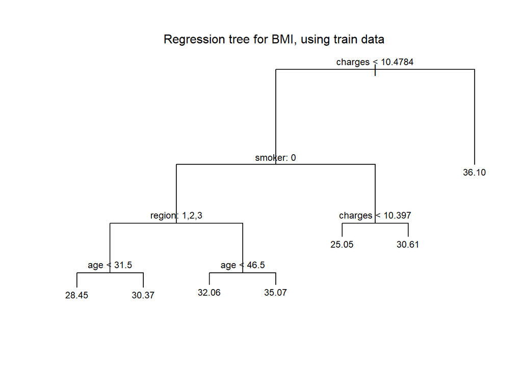

```r
ratio <- 0.7
total <- nrow(insurance)
train <- sample(1:total, as.integer(total * ratio))
tree.regression.bmi2 <- tree(bmi~., insurance, subset=train)
plot(tree.regression.bmi2)
text(tree.regression.bmi2, pretty=12, cex=0.75)
mtext("Regression tree for BMI, using train data \n")
```

```r
summary(tree.regression.bmi2)
```

```
##
## Regression tree:
## tree(formula = bmi ~ ., data = insurance, subset = train)
## Variables actually used in tree construction:
## [1] "charges" "smoker"  "region"  "age"
## Number of terminal nodes:  7
## Residual mean deviance:  27.84 = 25860 / 929
## Distribution of residuals:
##      Min.   1st Qu.    Median      Mean   3rd Qu.      Max.
## -13.55000  -3.46800  -0.09678   0.00000   3.35700  16.48000
```

Our residual mean deviance has furthermore gone from 29.23 to 27.84.

#### 7.1.2.4 Error Analysis

```r
tree.regression.bmi2.pred <- predict(tree.regression.bmi2, insurance[-train,], type="vector")
(RSS.2.train <- mean(((insurance[train,][3]-predict(tree.regression.bmi2, insurance[train,], type="vector"))^2)$bmi))
```

```
## [1] 27.63265
```

```r
(RSS.2.test <- mean(((insurance[-train,][3]-tree.regression.bmi2.pred)^2)$bmi))
```

```
## [1] 32.85365
```

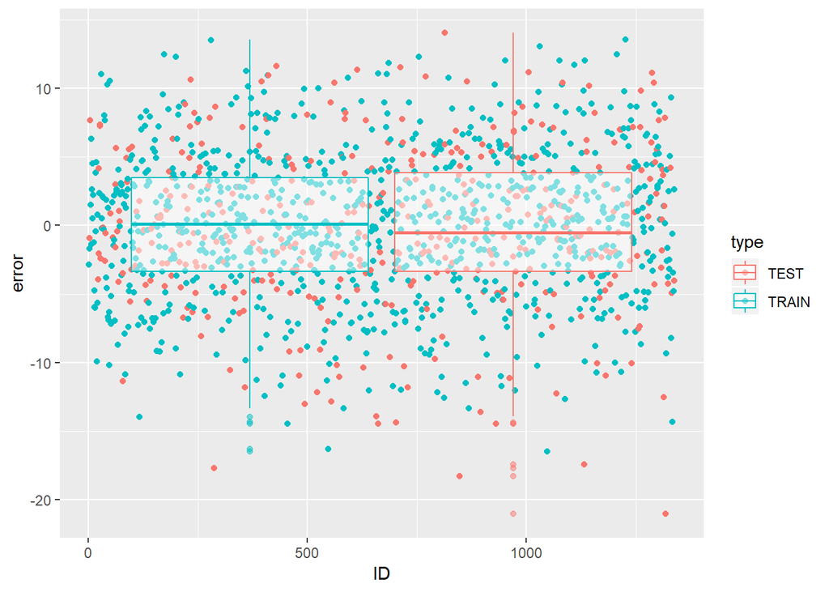

```r
errors.2.in <- predict(tree.regression.bmi2, insurance[train,], type="vector")-insurance[train,]$bmi
element.2.in <- as.integer(names(errors.2.in))
errors.2.in_dataframe <- tibble(element.2.in,errors.2.in,"TRAIN")
colnames(errors.2.in_dataframe) <- c('ID','error','type')
errors.2 <- predict(tree.regression.bmi2, insurance[-train,], type="vector")-insurance[-train,]$bmi
element.2 <- 1:length(errors.2)
element.2 <- as.integer(names(errors.2))
errors.2.out_dataframe <- tibble(element.2,errors.2,"TEST")
colnames(errors.2.out_dataframe) <- c('ID','error','type')
errors.2_dataframe <- bind_rows(errors.2.in_dataframe,errors.2.out_dataframe)
errors.2_dataframe <- arrange(errors.2_dataframe, ID)
ggplot(data = errors.2_dataframe, mapping = aes(x = ID,y = error, color = type)) +
  geom_point() + geom_boxplot(alpha = 0.5)
```

### 7.1.3 Regression tree - Charges

We now examine the behaviour of the variable “charges”. First off again with the entire data values.

```r
summary(insurance$charges)
```

```
##    Min. 1st Qu.  Median    Mean 3rd Qu.    Max.
##   7.023   8.464   9.147   9.099   9.720  11.063
```

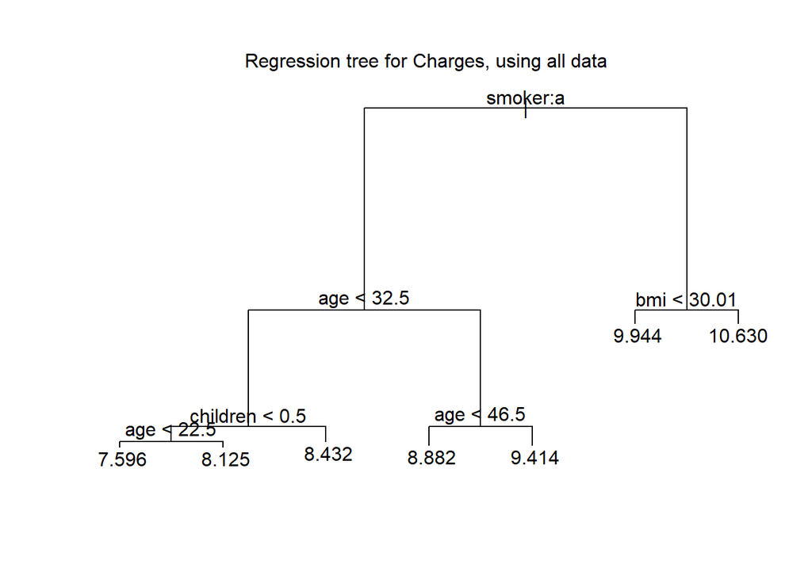

```r
tree.regression.charges <- tree(charges~., data=insurance)
plot(tree.regression.charges)
text(tree.regression.charges)
mtext("Regression tree for Charges, using all data \n")
```

If one smokes seems to be the crucial factor to start of the charges classification. We further receive a tree with seven end nodes and four influencing variables, as also the summary further demonstrates:

```r
summary(tree.regression.charges)
```

```
##
## Regression tree:
## tree(formula = charges ~ ., data = insurance)
## Variables actually used in tree construction:
## [1] "smoker"   "age"      "children" "bmi"
## Number of terminal nodes:  7
## Residual mean deviance:  0.1592 = 211.9 / 1331
## Distribution of residuals:
##     Min.  1st Qu.   Median     Mean  3rd Qu.     Max.
## -0.98730 -0.19690 -0.04999  0.00000  0.09942  2.45100
```

Our residual mean deviance (R-squared-error) us at 0.1592.

#### 7.1.3.1 Prediction

We are now again predicting the data that has already been used for training the model.

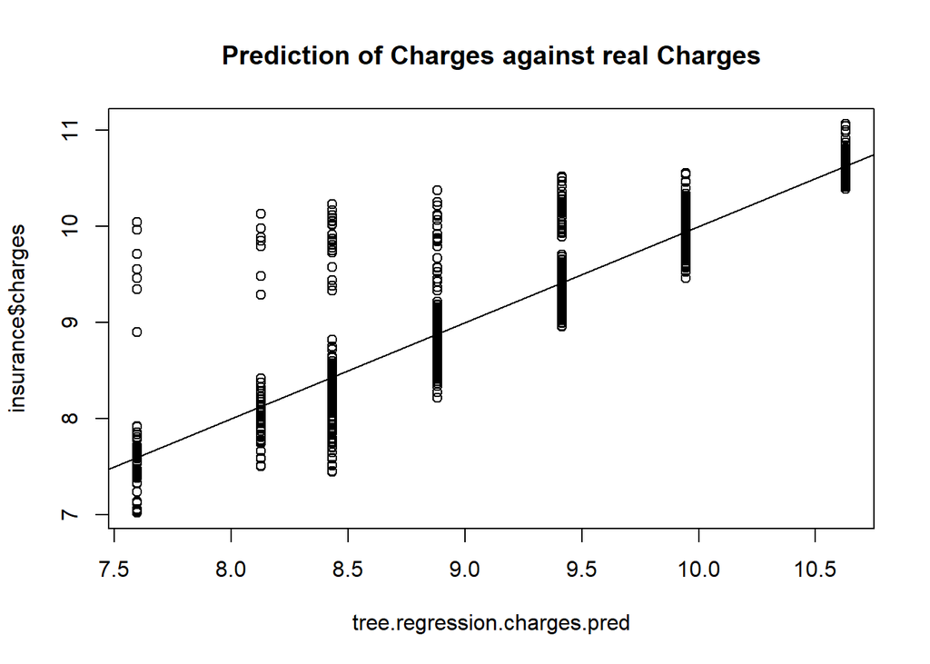

```r
tree.regression.charges.pred <- predict(tree.regression.charges, insurance, type="vector")
plot(tree.regression.charges.pred, insurance$charges, main="Prediction of Charges against real Charges")
abline(0 ,1)
```

We here see how our model predicts the charges to by (x-axis) in comparison to what the charges actually are.

#### 7.1.3.2 Comparison Prediction <-> True Values

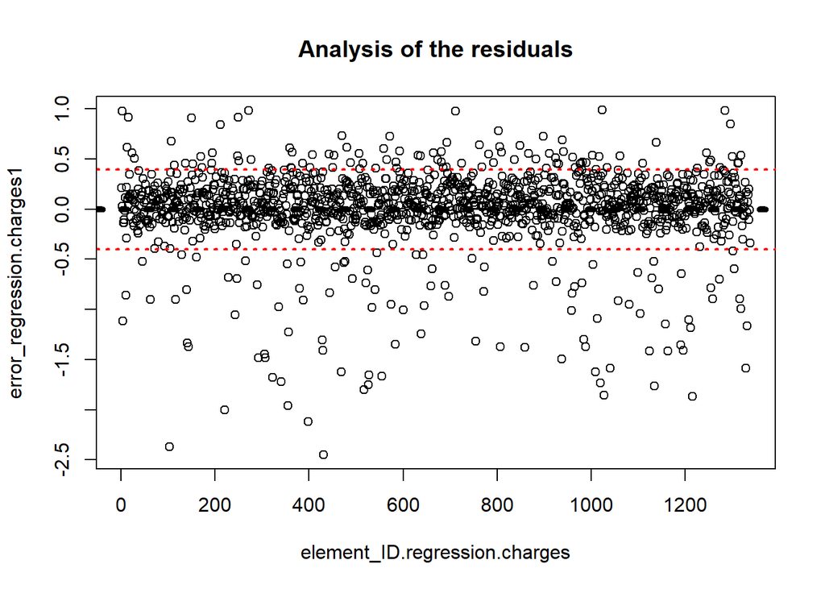

```r
error_regression.charges1 <- tree.regression.charges.pred-insurance$charges
element_ID.regression.charges <- 1:length(error_regression.charges1)
plot(element_ID.regression.charges, error_regression.charges1)
title(main="Analysis of the residuals")
abline(mean(error_regression.charges1),0, lwd=5,lty="dotted")
abline(sd(error_regression.charges1) ,0, lwd=2, col="red", lty="dotted")
abline(-sd(error_regression.charges1) ,0, lwd=2, col="red", lty="dotted")
```

We can furthermore clearly see that the residuals are roughly normalized, with an approximate mean of 0. Outliers are however more distributed in the negative axis of y than in the positive.

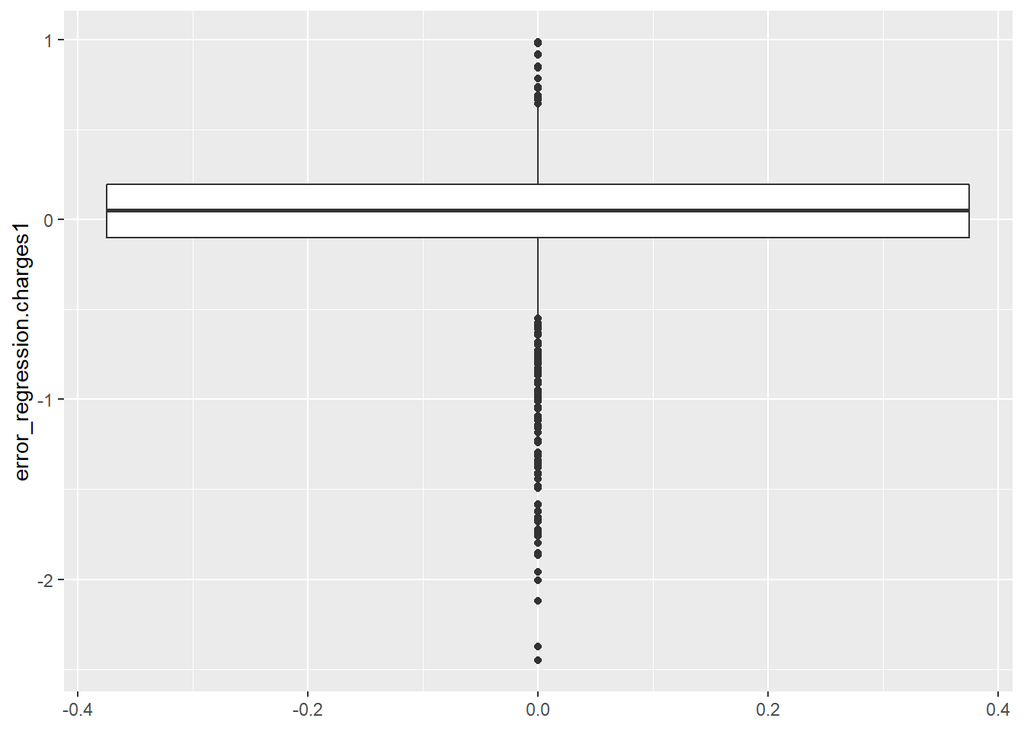

```r
error_regression1_dataframe.charges <- tibble(element_ID.regression.charges, error_regression.charges1)
ggplot(data=error_regression1_dataframe.charges) + geom_boxplot(aes(y=error_regression.charges1))
```

The above boxplot further demonstrates that there is a slight bias in the distribution.

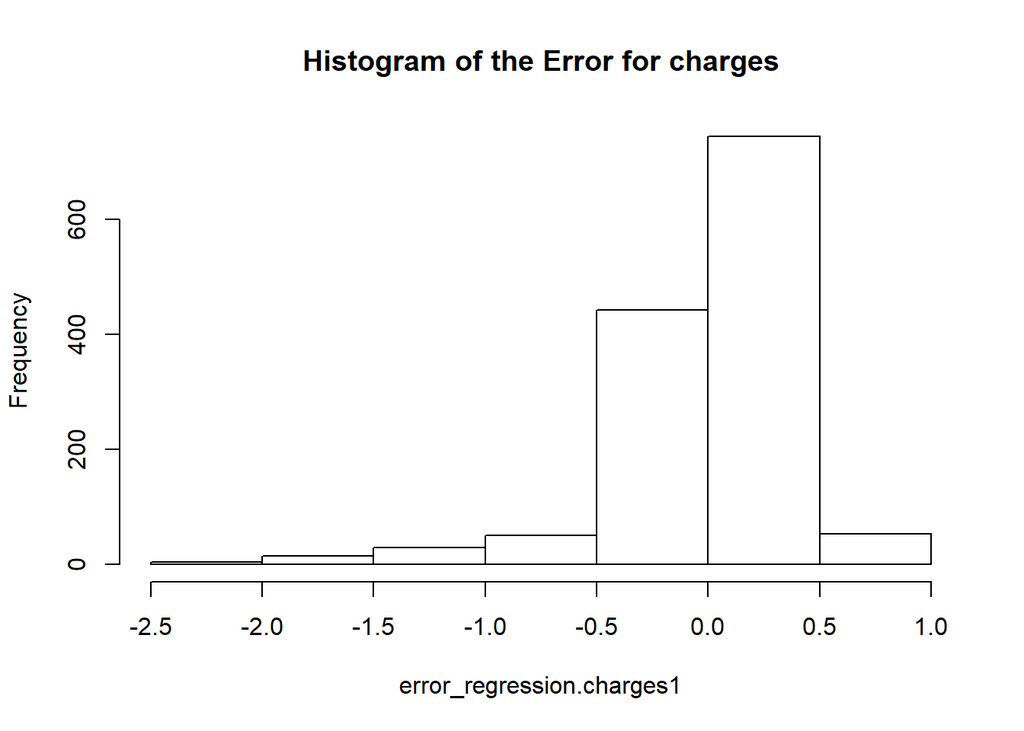

```r
hist(error_regression.charges1, main = "Histogram of the Error for charges")
```

```r
RSS_charges <- sum((insurance[7]-tree.regression.charges.pred)^2)
MSE_charges <- RSS_charges/length(tree.regression.charges.pred)
deviation_charges <- sqrt(MSE_charges)

cat(RSS_charges)
```

```
## 211.8598
```

```r
cat("\n")
```

```r
cat(deviation_charges)
```

```
## 0.3979204
```

RSS here is at 211.86, the deviation at 0.4.

#### 7.1.3.3 Train-Test-Approach

Again, we use the train-test approach to demonstrate the importance to not use all the data to train one’s model.

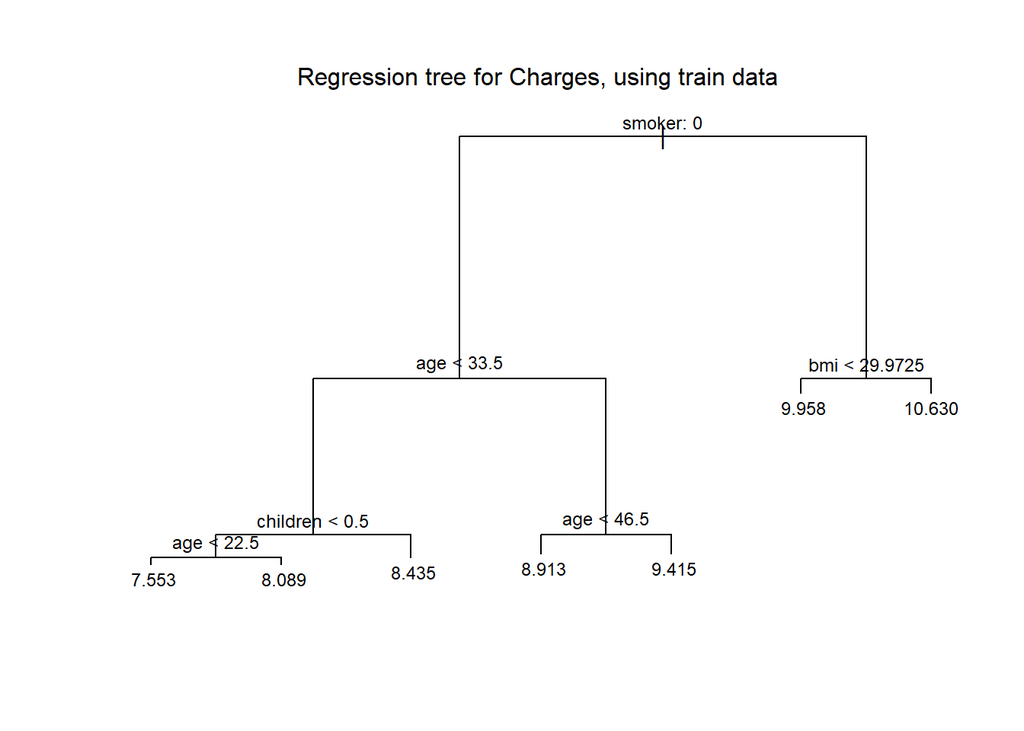

```r
ratio <- 0.7
total <- nrow(insurance)
train.charges <- sample(1:total, as.integer(total * ratio))
tree.regression.charges2 <- tree(charges~., insurance, subset=train)
plot(tree.regression.charges2)
text(tree.regression.charges2, pretty=12, cex=0.75)
mtext("Regression tree for Charges, using train data \n")
```

```r
summary(tree.regression.charges2)
```

```
##
## Regression tree:
## tree(formula = charges ~ ., data = insurance, subset = train)
## Variables actually used in tree construction:
## [1] "smoker"   "age"      "children" "bmi"
## Number of terminal nodes:  7
## Residual mean deviance:  0.1475 = 137 / 929
## Distribution of residuals:
##     Min.  1st Qu.   Median     Mean  3rd Qu.     Max.
## -0.98970 -0.18750 -0.04011  0.00000  0.10500  2.41600
```

Our residual mean deviance is now a bit lower at 0.1475 (previously: 0.1592)

```r
tree.regression.charges2.pred <- predict(tree.regression.charges2, insurance[-train,], type="vector")
(RSS.2.train.charges <- mean(((insurance[train,][7]-predict(tree.regression.charges2, insurance[train,], type="vector"))^2)$charges))
```

```
## [1] 0.146418
```

```r
(RSS.2.test.charges <- mean(((insurance[-train,][7]-tree.regression.charges2.pred)^2)$charges))
```

```
## [1] 0.196484
```

However, our train data, despite still having the same number of terminal nodes, is biased and thus shows an overfit. Hence it is that RSS for the train set is at e^0.146418, whereas for the test set, we are at e^0.196484.

#### 7.1.3.4 Errors

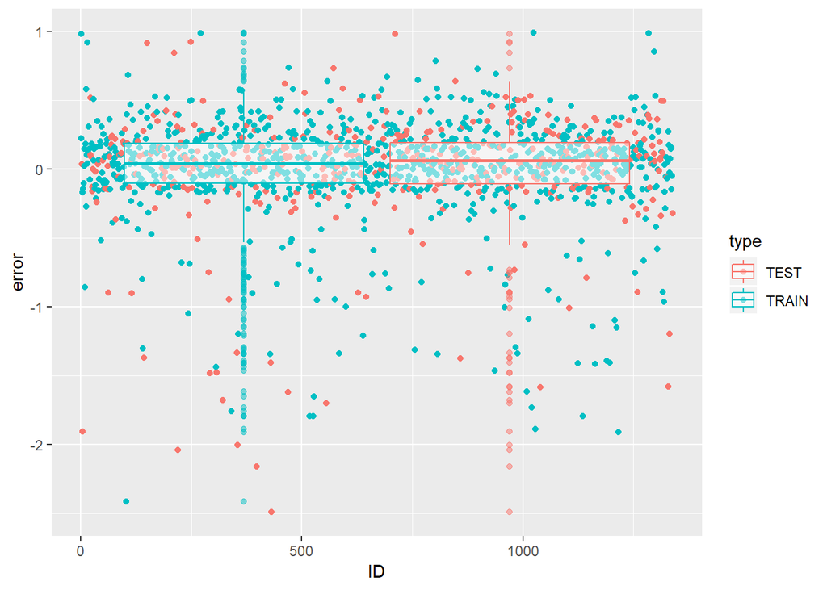

```r
errors.2.in.charges <- predict(tree.regression.charges2, insurance[train,], type="vector")-insurance[train,]$charges
element.2.in.charges <- as.integer(names(errors.2.in.charges))
errors.2.in_dataframe.charges <- tibble(element.2.in.charges,errors.2.in.charges,"TRAIN")
colnames(errors.2.in_dataframe.charges) <- c('ID','error','type')
errors.2.charges <- predict(tree.regression.charges2, insurance[-train,], type="vector")-insurance[-train,]$charges
element.2.charges <- 1:length(errors.2.charges)
element.2.charges <- as.integer(names(errors.2.charges))
errors.2.out_dataframe.charges <- tibble(element.2.charges,errors.2.charges,"TEST")
colnames(errors.2.out_dataframe.charges) <- c('ID','error','type')
errors.2_dataframe.charges <- bind_rows(errors.2.in_dataframe.charges,errors.2.out_dataframe.charges)
errors.2_dataframe.charges <- arrange(errors.2_dataframe.charges, ID)
ggplot(data = errors.2_dataframe.charges, mapping = aes(x = ID,y = error, color = type)) +
  geom_point() + geom_boxplot(alpha = 0.5)
```

There are a few differences, especially in regard of the outliers between the test and the train data. Roughly, one can say however that the boxplot is about the same for train and test. Also, the outliers in the negative area are for both data sets more spread.

## 7.2 Classification Trees

We here examine a decision tree for a non continuous (hence categorical) variable.

```r
tree.classification.region_all <- tree(region~., data=insurance)
summary(tree.classification.region_all)
```

```
##
## Classification tree:
## tree(formula = region ~ ., data = insurance)
## Variables actually used in tree construction:
## [1] "age" "bmi"
## Number of terminal nodes:  4
## Residual mean deviance:  2.604 = 3474 / 1334
## Misclassification error rate: 0.6547 = 876 / 1338
```

We here receive a classification tree with four end nodes. Furthermore our RMS is at 2.604 and the misclassification rate - which is basically the RSS for classification trees - is at 65.47%.

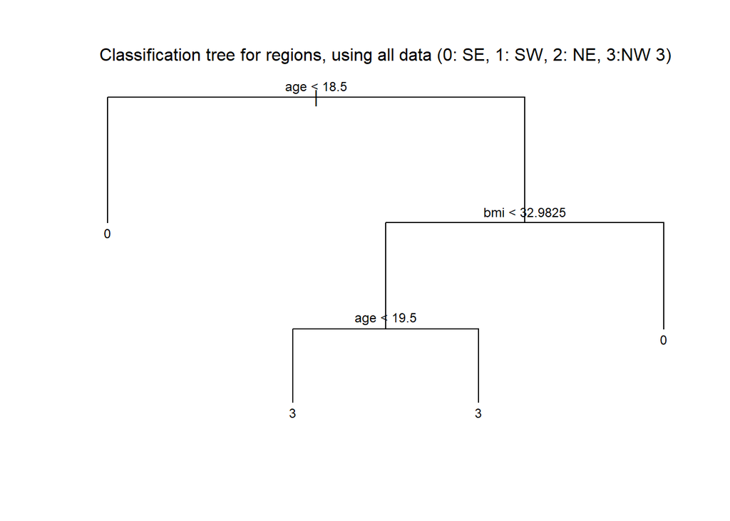

```r
plot(tree.classification.region_all)
text(tree.classification.region_all, pretty=1, cex=0.75)
mtext("Classification tree for regions, using all data (0: SE, 1: SW, 2: NE, 3:NW 3)\n")
```

It appears that the high misclassication rate is partly due to only 2 of the 4 factors being applied in the classification tree. Most important here is if one is under the age of 18.5 years (left branch) or above (right branch). We thus go into testing mode:

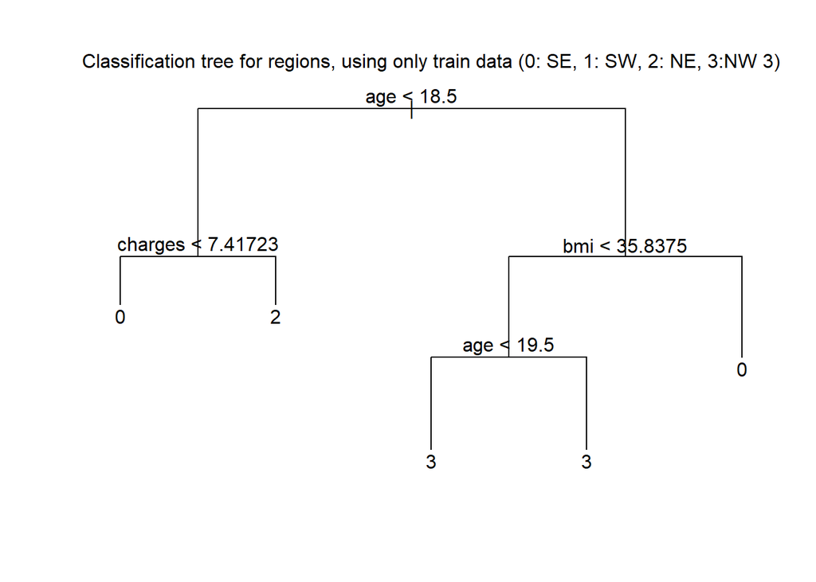

```r
tree.classification.region <- tree(region~., data=insurance, subset=train)
plot(tree.classification.region)
text(tree.classification.region)
mtext("Classification tree for regions, using only train data (0: SE, 1: SW, 2: NE, 3:NW 3)\n")
```

Working with our training set, we see a clear change: we now have five terminal nodes as well as the factor of 2 –> “northeast” that is not part of the equation.

```r
tree.classification.region.pred <- predict(tree.classification.region, insurance[train,], type="class")
```

### 7.2.1 Confusion Table for Train Data

We now examine the classification error on the train data by comparing the estimation with the true value to elaborate how exact our trained model works.

```r
tree.classification.region.pred.ct <- table(tree.classification.region.pred, insurance[train,]$region)
tree.classification.region.pred.correct <- 0
tree.classification.region.pred.error <- 0
for (i1 in 1:4) {
  for (i2 in 1:4) {
    if (i1 == i2) {
      tree.classification.region.pred.correct <- tree.classification.region.pred.correct + tree.classification.region.pred.ct[i1,i2]
    }else{
      tree.classification.region.pred.error <- tree.classification.region.pred.error + tree.classification.region.pred.ct[i1,i2]
    }
  }
}
tree.classification.region.pred.rate <- tree.classification.region.pred.correct/sum(tree.classification.region.pred.ct)
tree.classification.region.pred.error.1 <- 1 - tree.classification.region.pred.rate
cat(tree.classification.region.pred.rate)
```

```
## 0.357906
```

```r
cat("\n")
```

```r
cat(tree.classification.region.pred.error.1)
```

```
## 0.642094
```

Our “new” tree manages to reduce our classification error by about 1% for the train data.

### 7.2.2 Confusion Table for Test Data

```r
tree.classification.region.pred.test <- predict(tree.classification.region, insurance[-train,], type="class")
```

We now determine the classification error on our test data:

```r
(tree.classification.region.pred.test.ct <- table(tree.classification.region.pred.test, insurance[-train,]$region))
```

```
##
## tree.classification.region.pred.test  0  1  2  3
##                                    0 41 14 16  9
##                                    1  0  0  0  0
##                                    2  3  0  8  0
##                                    3 73 81 79 78
```

```r
tree.classification.region.pred.correct <- 0
tree.classification.region.pred.error <- 0
for (i1 in 1:3) {
  for (i2 in 1:3) {
    if (i1 == i2) {
      tree.classification.region.pred.correct <- tree.classification.region.pred.correct + tree.classification.region.pred.test.ct[i1,i2]
    }else{
      tree.classification.region.pred.error <- tree.classification.region.pred.error + tree.classification.region.pred.test.ct[i1,i2]
    }
  }
}
(tree.classification.region.pred.rate <- tree.classification.region.pred.correct/sum(tree.classification.region.pred.test.ct))
```

```
## [1] 0.1218905
```

```r
(tree.classification.region.pred.error.2 <- 1 - tree.classification.region.pred.rate)
```

```
## [1] 0.8781095
```

Whereas the model performed a bit better with the train data in comparison with the entire data set, the model now clearly performs in an all time bad. The training model is thus a clear overfit.

It seems that region, considering the constant high error quote for entire data set, train set as well as test set, is not a variable that has a large connection with the other variables used.

## 7.3 Pruning

We now continue to prune the trees as so far, we actually managed to create an overfit of our train data in comparison to our test data.

### 7.3.1 Pruning the continuous BMI variable

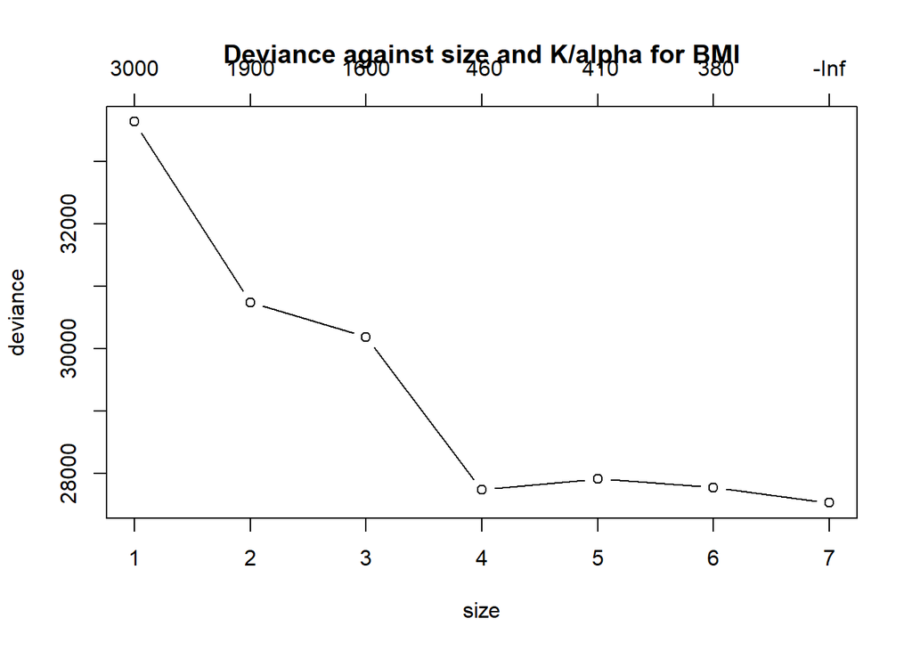

```r
tree.regression.bmi.pruning = cv.tree(tree.regression.bmi2, FUN = prune.tree)
plot(tree.regression.bmi.pruning, type = "b")
title("Deviance against size and K/alpha for BMI")
```

```r
tree.regression.bmi.pruning
```

```
## $size
## [1] 7 6 5 4 3 2 1
##
## $dev
## [1] 27530.68 27774.88 27914.67 27741.44 30188.86 30746.46 33641.26
##
## $k
## [1]      -Inf  376.0091  414.7563  462.4535 1571.4867 1872.8382 3018.0179
##
## $method
## [1] "deviance"
##
## attr(,"class")
## [1] "prune"         "tree.sequence"
```

What is interesting to see is that between the number of end nodes 4 and 7, there is a slight growth as well as decline in terms of variance, so the slope inbetween is both negative as well as positive.

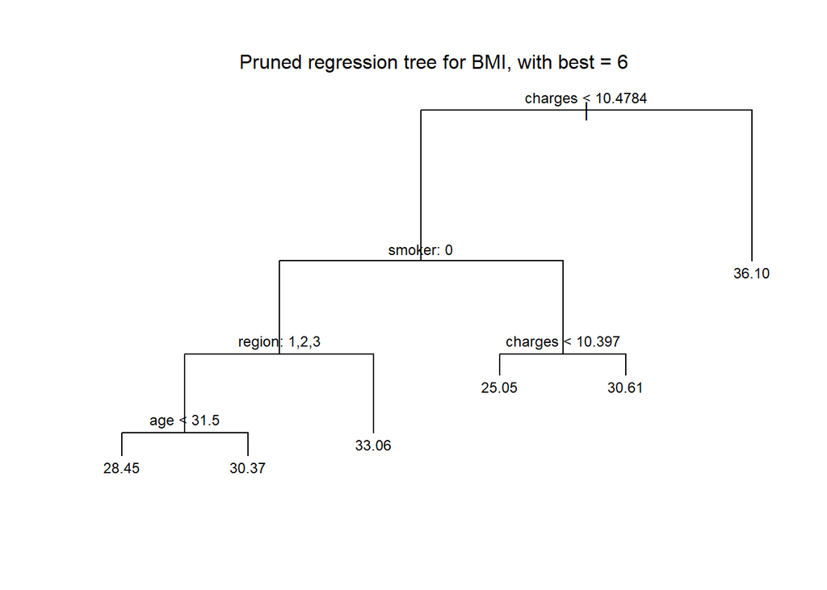

```r
tree.regression.bmi.pruned <- prune.tree(tree.regression.bmi2, best = 6)

plot(tree.regression.bmi.pruned)
text(tree.regression.bmi.pruned, pretty=1, cex=0.75)
mtext("Pruned regression tree for BMI, with best = 6 \n")
```

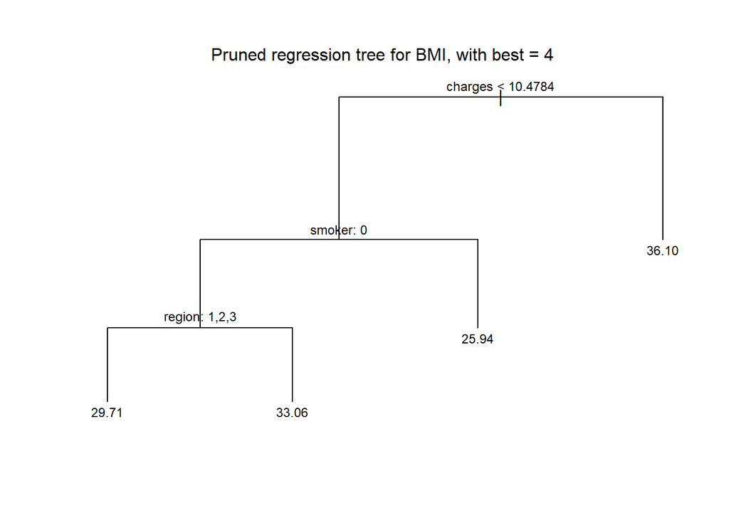

```r
tree.regression.bmi.pruned2 <- prune.tree(tree.regression.bmi2, best = 4)

plot(tree.regression.bmi.pruned2)
text(tree.regression.bmi.pruned2, pretty=1, cex=0.75)
mtext("Pruned regression tree for BMI, with best = 4 \n")
```

```r
summary(tree.regression.bmi.pruned)
```

```
##
## Regression tree:
## snip.tree(tree = tree.regression.bmi2, nodes = 9L)
## Variables actually used in tree construction:
## [1] "charges" "smoker"  "region"  "age"
## Number of terminal nodes:  6
## Residual mean deviance:  28.22 = 26240 / 930
## Distribution of residuals:
##      Min.   1st Qu.    Median      Mean   3rd Qu.      Max.
## -13.55000  -3.57100  -0.09678   0.00000   3.33800  16.48000
```

```r
summary(tree.regression.bmi.pruned2)
```

```
##
## Regression tree:
## snip.tree(tree = tree.regression.bmi2, nodes = c(9L, 5L, 8L))
## Variables actually used in tree construction:
## [1] "charges" "smoker"  "region"
## Number of terminal nodes:  4
## Residual mean deviance:  29.1 = 27120 / 932
## Distribution of residuals:
##    Min. 1st Qu.  Median    Mean 3rd Qu.    Max.
## -13.750  -3.680  -0.110   0.000   3.635  16.990
```

In comparison, we can say that the tree with four end nodes more or less performs the same as the tree with six end nodes. Of course, for the tree with 6 leaves, the residual mean deviance is a bit lower than for four. In terms of internal nodes however, the construction of the tree is roughly the same - with, of course, the exception of the two additional splits for which is also used an additional variable in comparison, namely “age”.

```r
(RSS.cv.bmi.test <- sum((insurance[train,][3]-predict(tree.regression.bmi.pruned, insurance[train,], type="vector"))^2)/nrow(insurance[train,]))
```

```
## [1] 28.03437
```

```r
tree.regression.bmi.pruned.pred <- predict(tree.regression.bmi.pruned, insurance[-train,], type="vector")
(RSS.cv <- sum((insurance[-train,][3]-tree.regression.bmi.pruned.pred)^2)/length(tree.regression.bmi.pruned.pred))
```

```
## [1] 31.87446
```

### 7.3.2 Pruning regions

```r
tree.classification.region.pruning <- cv.tree(tree.classification.region, FUN = prune.misclass)
summary(tree.classification.region.pruning)
```

```
##        Length Class  Mode
## size   4      -none- numeric
## dev    4      -none- numeric
## k      4      -none- numeric
## method 1      -none- character
```

```r
tree.classification.region.pruning
```

```
## $size
## [1] 5 4 3 1
##
## $dev
## [1] 640 640 648 712
##
## $k
## [1] -Inf    0   10   39
##
## $method
## [1] "misclass"
##
## attr(,"class")
## [1] "prune"         "tree.sequence"
```

We have a length of four whereas the size of four is the optimal size.

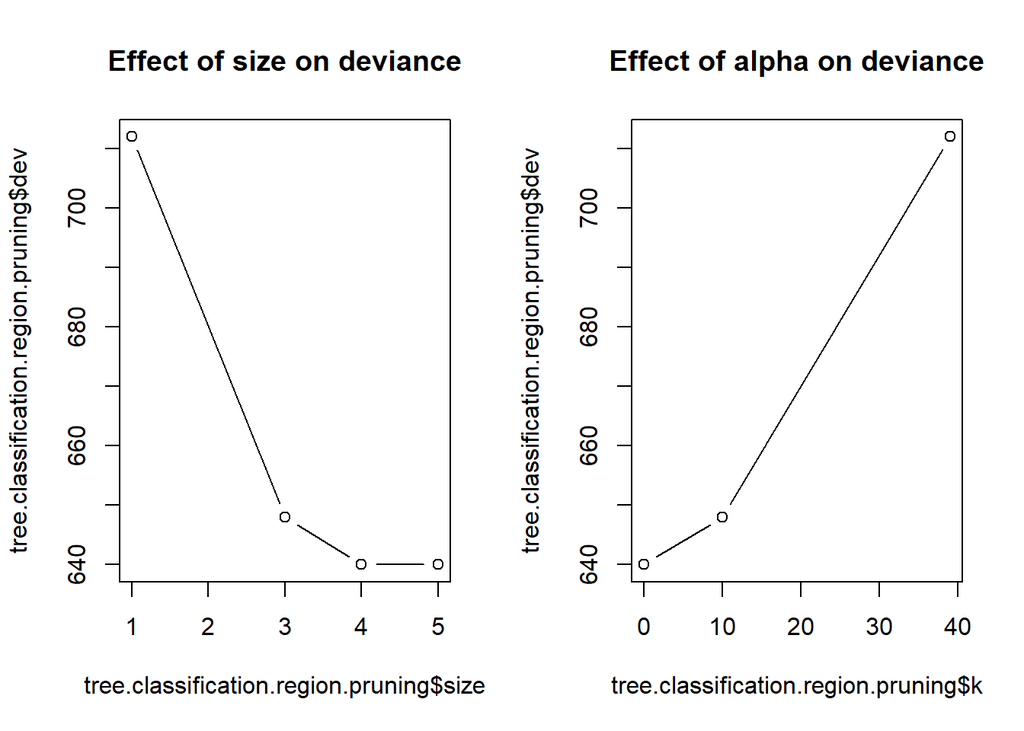

```r
par(mfrow=c(1,2))
plot(tree.classification.region.pruning$size, tree.classification.region.pruning$dev, type="b", main = "Effect of size on deviance")
plot(tree.classification.region.pruning$k, tree.classification.region.pruning$dev, type="b", main= "Effect of alpha on deviance")
```

```r
par(mfrow=c(1,1))
```

We go with three for the further processing of pruning this decision tree, as it combines low values in both illustrations above, thus is good in terms of a low deviance.

```r
prune.tree.classification.region <- prune.misclass(tree.classification.region, best=3)

summary (prune.tree.classification.region)
```

```
##
## Classification tree:
## snip.tree(tree = tree.classification.region, nodes = c(6L, 2L
## ))
## Variables actually used in tree construction:
## [1] "age" "bmi"
## Number of terminal nodes:  3
## Residual mean deviance:  2.633 = 2456 / 933
## Misclassification error rate: 0.6528 = 611 / 936
```

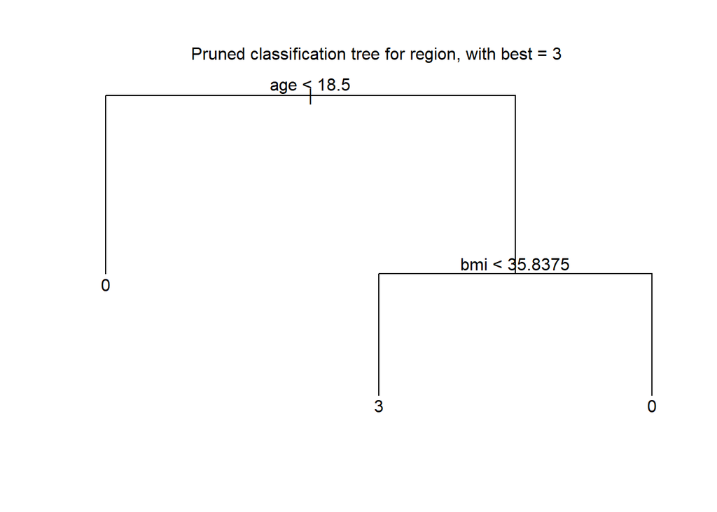

```r
plot(prune.tree.classification.region)
text(prune.tree.classification.region,pretty=0)
mtext("Pruned classification tree for region, with best = 3 \n")
```

The residual mean deviane is at 2.633 whereas the misclassification error is at 65.28%.

```r
prune.tree.classification.region2 <- prune.misclass(tree.classification.region, best=5)
summary (prune.tree.classification.region2)
```

```
##
## Classification tree:
## tree(formula = region ~ ., data = insurance, subset = train)
## Variables actually used in tree construction:
## [1] "age"     "charges" "bmi"
## Number of terminal nodes:  5
## Residual mean deviance:  2.555 = 2379 / 931
## Misclassification error rate: 0.6421 = 601 / 936
```

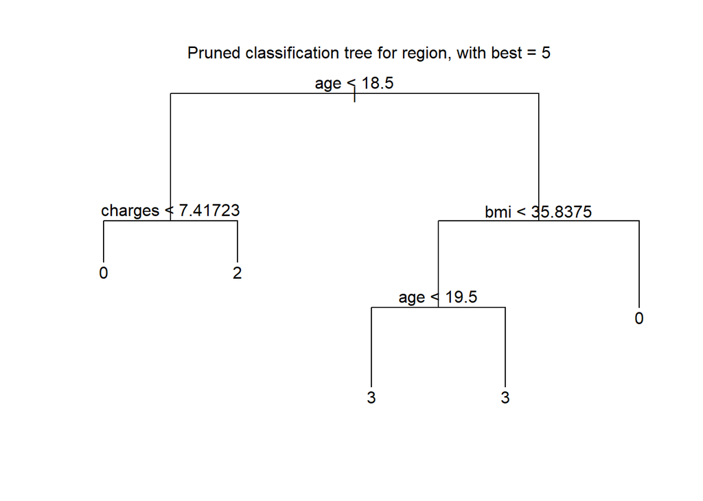

```r
plot(prune.tree.classification.region2)
text(prune.tree.classification.region2,pretty=0)
mtext("Pruned classification tree for region, with best = 5 \n")
```

The residual mean deviane is at 2.555 with a misclassification error rate of 0.6421.

We now make a prediction on our test data:

```r
prune.tree.classification.region.pred <- predict(prune.tree.classification.region,  insurance[-train,], type="class")

(prune.tree.classification.region.pred.ct <- table(prune.tree.classification.region.pred, insurance[-train,]$region))
```

```
##
## prune.tree.classification.region.pred  0  1  2  3
##                                     0 44 14 24  9
##                                     1  0  0  0  0
##                                     2  0  0  0  0
##                                     3 73 81 79 78
```

```r
(prune.tree.classification.region.pred.correct <- sum(prune.tree.classification.region.pred==insurance[-train,]$region)/sum(prune.tree.classification.region.pred.ct))
```

```
## [1] 0.3034826
```

```r
prune.tree.classification.region.pred.testError <- 1 - prune.tree.classification.region.pred.correct
```

```r
cat(tree.classification.region.pred.error)
```

[output not shown]

```r
cat("\n")
```

```r
cat(prune.tree.classification.region.pred.testError)
```

```
## 0.6965174
```

However, despite the classification rate still being very low, in comparison, the error has drastically reduced in comparison with the unpruned tree.

## 7.4 Bagging

```r
set.seed (5)
train <- sample(1:nrow(insurance), nrow(insurance)/2)
insurance.test=insurance[-train ,]
```

We now are bagging our dataset. We furthermore say that we are happy with an estimation and not the real crossvalidation.

```r
bag.insurance <- bagging(charges~., data=insurance, subset=train, nbagg=20, coob = TRUE)
print(bag.insurance)
```

```
##
## Bagging regression trees with 20 bootstrap replications
##
## Call: bagging.data.frame(formula = charges ~ ., data = insurance, subset = train,
##     nbagg = 20, coob = TRUE)
##
## Out-of-bag estimate of root mean squared error:  0.391
```

We here receive a root mean squared error of 0.391 –> mean squared error = 0.152881 (as the results one receives is rooted).

We now predict performance from our bagged model:

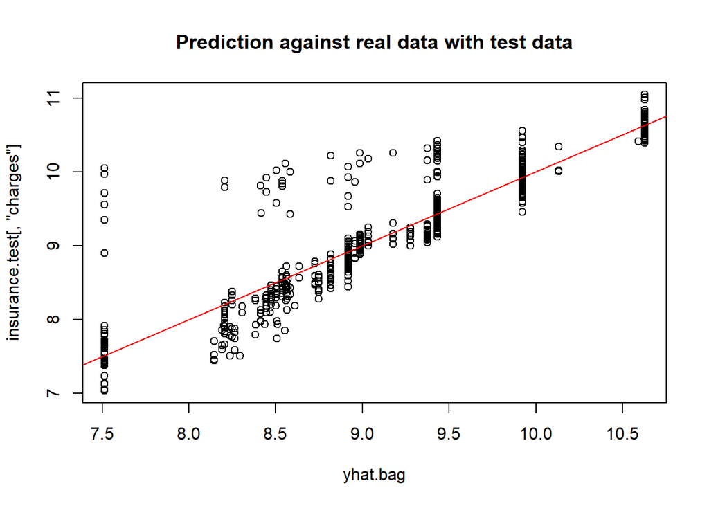

```r
yhat.bag <- predict(bag.insurance, newdata=insurance[-train,])
plot(yhat.bag, insurance.test[,"charges"], main="Prediction against real data with test data")
abline(0,1, col="red")
```

On the x-axis, we see the prediction, whereas on the y-axis, the real value (logarithmic).

We also compute the mean: in comparison with the previously calculated mean value, we can say they are rather related than not, however with some deviance.

```r
mean((yhat.bag-insurance.test[,"charges"])^2)
```

```
## [1] 0.1575089
```

We also test this with the random forest way to do it.

```r
## test with randomForest
bag.insurance.2 <- randomForest(charges~., data=insurance, subset=train, mtry=6, importance =TRUE)
print(bag.insurance.2)
```

```
##
## Call:
##  randomForest(formula = charges ~ ., data = insurance, mtry = 6,      importance = TRUE, subset = train)
##                Type of random forest: regression
##                      Number of trees: 500
## No. of variables tried at each split: 6
##
##           Mean of squared residuals: 0.1497648
##                     % Var explained: 82.09
```

```r
importance(bag.insurance.2)
```

```
##             %IncMSE IncNodePurity
## age      155.286361    212.223089
## sex        4.046307      3.899614
## bmi       28.599394     42.827102
## children  39.871574     32.346164
## smoker   164.251751    241.621328
## region     8.898203     13.246871
```

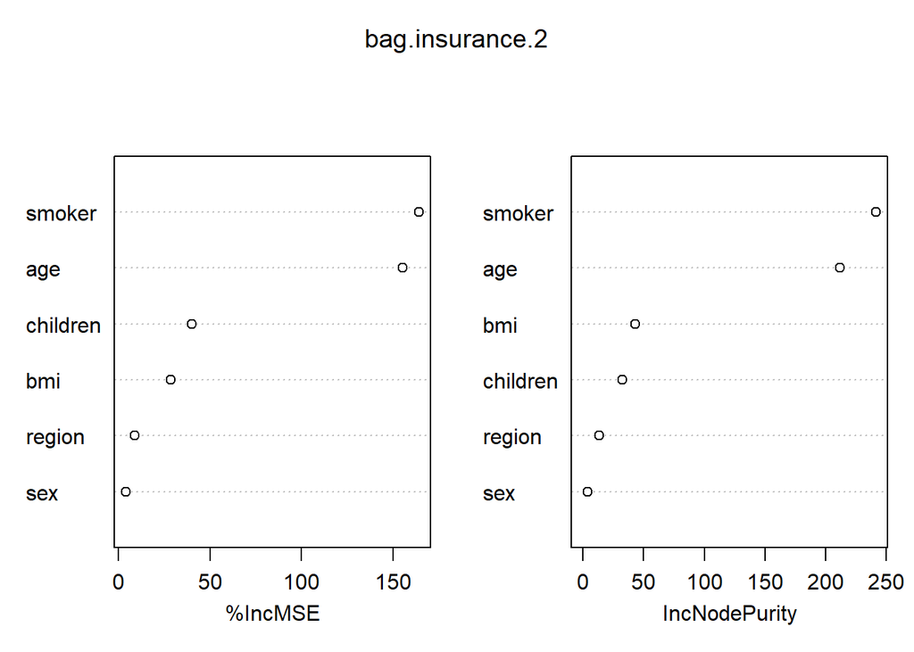

```r
varImpPlot(bag.insurance.2)
```

We here see that age and if one smokes are of biggest influence on charges. Age also seems fairly important.

## 7.5 Random Forests

```r
set.seed(10)
rf.insurance <- randomForest(charges~.,data=insurance,subset=train, mtry=2,importance =TRUE)
yhat.rf <- predict(rf.insurance ,newdata=insurance[-train ,])
mean((yhat.rf-insurance.test[,"charges"])^2)
```

```
## [1] 0.158069
```

```r
importance(rf.insurance)
```

```
##             %IncMSE IncNodePurity
## age       86.489219    182.623763
## sex        3.084226      6.073046
## bmi       18.476454     50.077296
## children  29.481898     25.129388
## smoker   118.440509    225.385251
## region     9.858480     14.461133
```

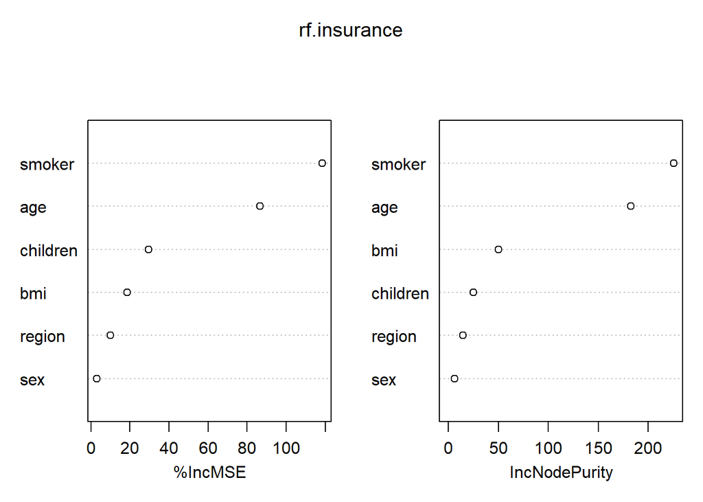

```r
varImpPlot (rf.insurance)
```

## 7.6 Boosting

We now perform boosting by a generalized boosted regression modelling:

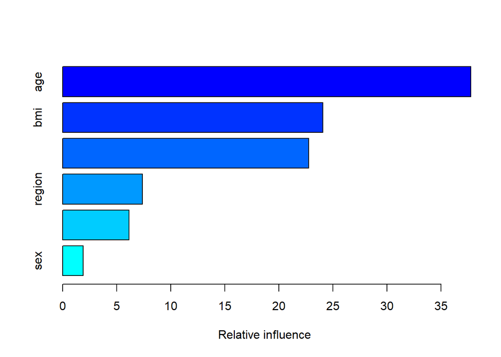

```
##               var   rel.inf
## age           age 37.751923
## bmi           bmi 24.084978
## smoker     smoker 22.759940
## region     region  7.370245
## children children  6.137392
## sex           sex  1.895522
```

```r
set.seed (1)
boost.insurance <- gbm(charges~.,data=insurance[train,],
                 distribution="gaussian",n.trees=5000, interaction.depth=4)
summary(boost.insurance)
```

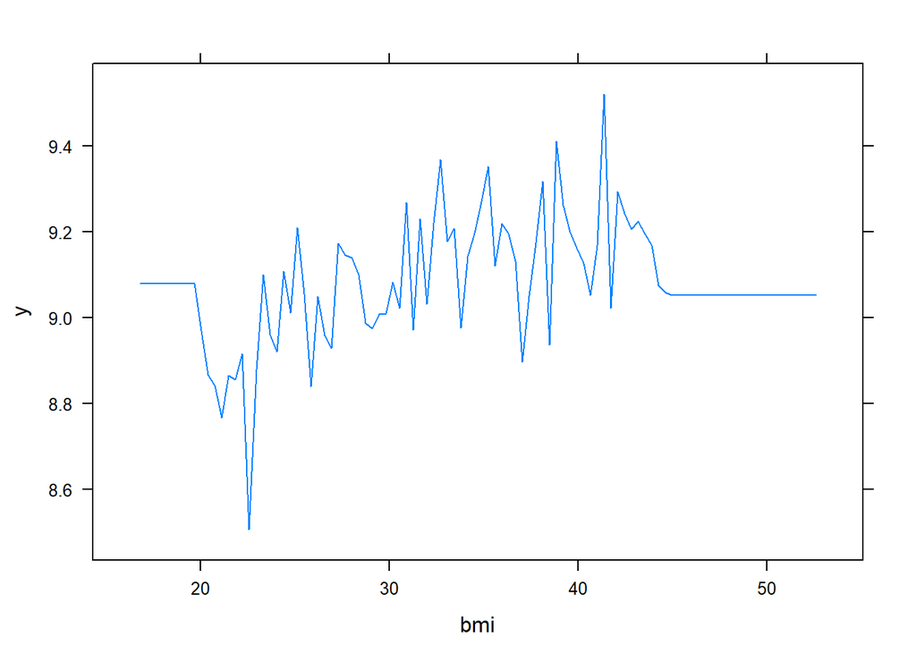

```r
plot(boost.insurance ,i="bmi")
```

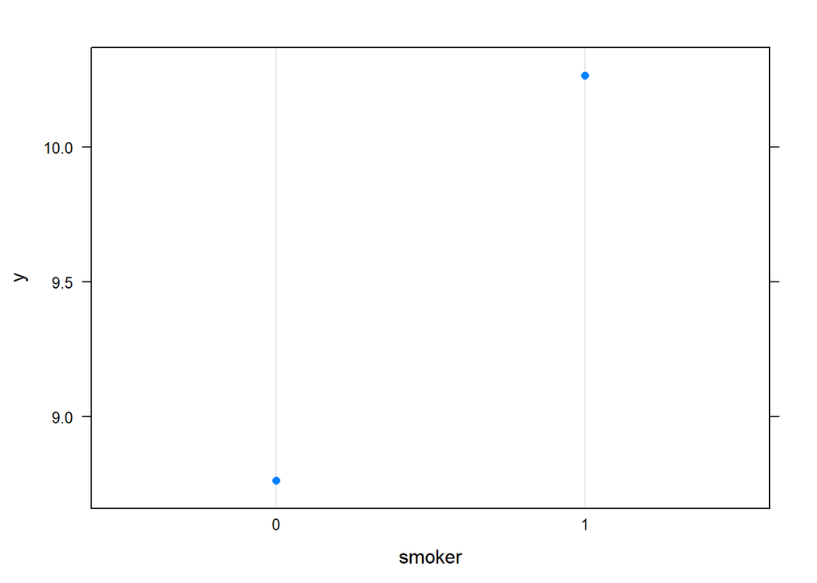

```r
plot(boost.insurance ,i="smoker")
```

We now do a prediction with the boosted model.

```r
yhat.boost <- predict(boost.insurance, newdata=insurance[-train,], n.trees=5000)
mean((yhat.boost -insurance.test[,"charges"])^2)
```

```
## [1] 0.2383602
```

The output is our MSE = 0.2383602.

We now are resetting shrinkage /lambda parameter which expresses basically that we have an overfit effect faster:

```r
boost.insurance = gbm(charges~.,data=insurance[train,],distribution="gaussian",n.trees=5000, interaction.depth=4,shrinkage = 0.02, verbose = FALSE)
yhat.boost2=predict(boost.insurance,newdata=insurance[-train,], n.trees=5000)
mean((yhat.boost2 -insurance.test[,"charges"])^2)
```

```
## [1] 0.193239
```

We now receive a smaller error rate, so one could say this is a better model.

And we do the same thing again but on the other side:

```r
boost.insurance2=gbm(charges~.,data=insurance[train,],distribution="gaussian",n.trees=5000, interaction.depth=4,shrinkage = 0.2, verbose = FALSE)
yhat.boost3=predict(boost.insurance2,newdata=insurance[-train,], n.trees=5000)
mean((yhat.boost -insurance.test[,"charges"])^2)
```

```
## [1] 0.2383602
```

(Attention: Please do only execute the code block (applying the exponential function) below once as executing it several times will apply the function several times)

```r
insurance$charges <- exp(insurance$charges) #resetting the insurance variable
```

# 8 Support Vector Machines

In this chapter, Support Vector Machines are applied to the insurance dataset.

## 8.1 two classes linear

By visual exploration, we discover that smokers and non-smokers form two groups. We fit an SVM for those two groups. The lines in the graph are the first guess of how the data could be divided.

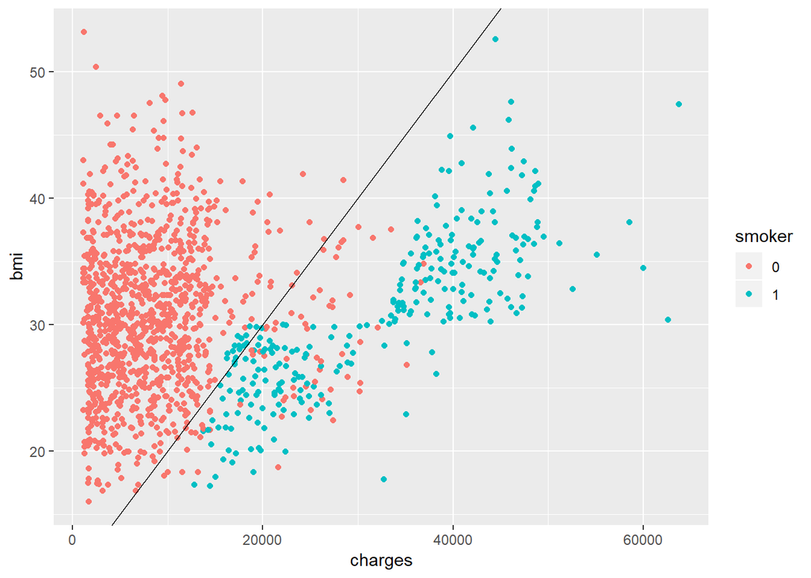

```r
# guess of hyperplane
slope <- 0.001
intercept <- 10
ggplot(data = insurance) +
  geom_point(aes(x = charges, y = bmi, color=smoker))+
  geom_abline(slope = slope, intercept = intercept)
```

A linear SVM is tuned using different cost ranges.

```r
  # prepare data

  train.YES <- sample(x=c(TRUE,FALSE),
                      size=nrow(insurance),
                      replace = TRUE)

  table(train.YES)
```

```
## train.YES
## FALSE  TRUE
##   688   650
```

```r
  insurance.train <- insurance[train.YES, ]
  insurance.test <- insurance[!train.YES, ]
```

```r
set.seed(5)
#get optimal cost
cost_range <-
  c(1e-10,
    1e-7,
    1e-5,
    0.001,
    0.0025,
    0.005,
    0.0075,
    0.01,
    0.1,
    1,
    5,
    10,
    100,
    200)
tune.out.1 <- tune(
  svm,
  smoker ~ charges+bmi,
  data = insurance.train,
  kernel = "linear",
  ranges = list(cost = cost_range)
)
```

```r
#best model
bestmod <- tune.out.1$best.model
summary(bestmod)
```

```
##
## Call:
## best.tune(method = svm, train.x = smoker ~ charges + bmi, data = insurance.train,
##     ranges = list(cost = cost_range), kernel = "linear")
##
##
## Parameters:
##    SVM-Type:  C-classification
##  SVM-Kernel:  linear
##        cost:  10
##
## Number of Support Vectors:  100
##
##  ( 50 50 )
##
##
## Number of Classes:  2
##
## Levels:
##  0 1
```

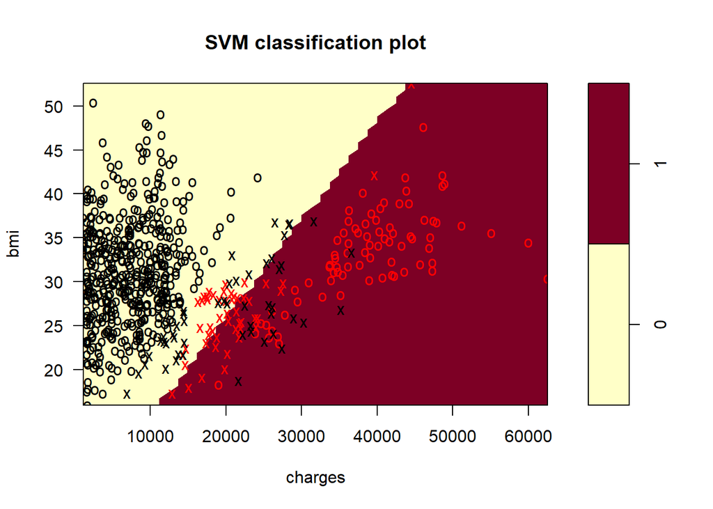

```r
plot(bestmod, insurance.train, bmi~charges)
```

The confision matrices and the classifiaction error rate for train and test data are:

```r
# confusion matrix train
confusion.lin.train <- table(predict = predict(bestmod, insurance.train),
      truth = insurance.train$smoker)
confusion.lin.train
```

```
##        truth
## predict   0   1
##       0 501  20
##       1  20 109
```

```r
#classification error rate train
(confusion.lin.train[1,2]+confusion.lin.train[2,1])/sum(confusion.lin.train[1:2,1:2])
```

```
## [1] 0.06153846
```

```r
# confusion matrix linear test
confusion.lin.test <- table(predict = predict(bestmod, insurance.test),
      truth = insurance.test$smoker)
confusion.lin.test
```

```
##        truth
## predict   0   1
##       0 523  26
##       1  20 119
```

```r
#classification error rate test
(confusion.lin.test[1,2]+confusion.lin.test[2,1])/sum(confusion.lin.test[1:2,1:2])
```

```
## [1] 0.06686047
```

## 8.2 two classes polynomial

A polynomial model was also tested but the classification error rate was slightly higher:

```r
set.seed(5)
#get optimal cost and degree for polynomial
cost_range <-
  c(1e-10,
    1e-7,
    1e-5,
    0.001,
    0.0025,
    0.005,
    0.0075,
    0.01,
    0.1,
    1,
    5,
    10,
    100)
degree_range <- 2:4
tune.out.poly <- tune(
  svm,
  smoker ~ charges+bmi,
  data = insurance.train,
  kernel = "polynomial",
  ranges = list(cost = cost_range, degree = degree_range))
#best model poly
tune.out.poly$best.parameters
```

```
##    cost degree
## 24    5      3
```

```r
bestmod.poly <- tune.out.poly$best.model
summary(bestmod.poly)
```

```
##
## Call:
## best.tune(method = svm, train.x = smoker ~ charges + bmi, data = insurance.train,
##     ranges = list(cost = cost_range, degree = degree_range),
##     kernel = "polynomial")
##
##
## Parameters:
##    SVM-Type:  C-classification
##  SVM-Kernel:  polynomial
##        cost:  5
##      degree:  3
##      coef.0:  0
##
## Number of Support Vectors:  115
##
##  ( 58 57 )
##
##
## Number of Classes:  2
##
## Levels:
##  0 1
```

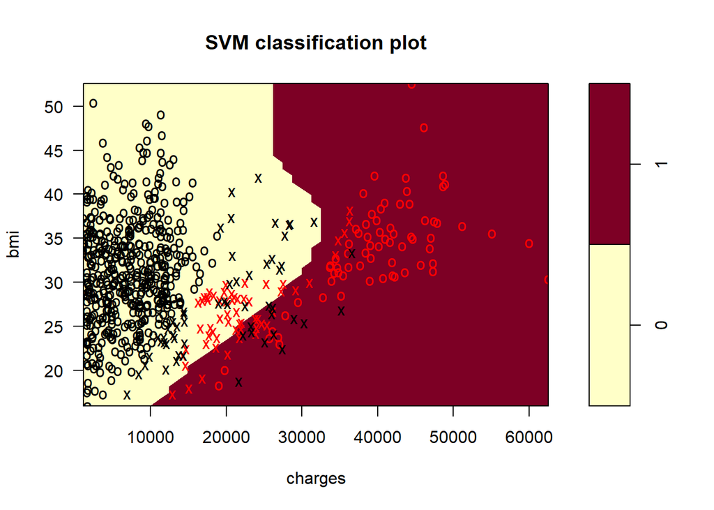

```r
plot(bestmod.poly, insurance.train, bmi~charges)
```

```r
# confusion matrix
confusion.poly.train <- table(predict = predict(bestmod.poly, insurance.train),
      truth = insurance.train$smoker)
confusion.poly.test <- table(predict = predict(bestmod.poly, insurance.test),
      truth = insurance.test$smoker)
#classification error rate
(confusion.poly.train[1,2]+confusion.poly.train[2,1])/sum(confusion.poly.train[1:2,1:2])
```

```
## [1] 0.07230769
```

```r
(confusion.poly.test[1,2]+confusion.poly.test[2,1])/sum(confusion.poly.test[1:2,1:2])
```

```
## [1] 0.07122093
```

# 9 Neural Networks

## 9.1 Neural Networks using “neuralnet”

In this section we will create and train a neural network which should be able to classify if a person is a smoker (output) based on the information of age, bmi and charges that are provided as input factors for the model. The assumption of the input variables is retrieved from our analysis already done in section 6. Generalized Linear Models.

### 9.1.1 Cleaning and Normalization

This part will be needed to ensure a cleansed and normalized database for a proper modelling of neural networks.

```r
#setwd("~/GitHub/machinelearning/machinelearning/03_rmarkdown") #adrianas extrawurst
insurance <- read.csv("../01_data/insurance.csv", header=TRUE)
str(insurance)
```

```
## 'data.frame':    1338 obs. of  7 variables:
##  $ age     : int  19 18 28 33 32 31 46 37 37 60 ...
##  $ sex     : Factor w/ 2 levels "female","male": 1 2 2 2 2 1 1 1 2 1 ...
##  $ bmi     : num  27.9 33.8 33 22.7 28.9 ...
##  $ children: int  0 1 3 0 0 0 1 3 2 0 ...
##  $ smoker  : Factor w/ 2 levels "no","yes": 2 1 1 1 1 1 1 1 1 1 ...
##  $ region  : Factor w/ 4 levels "northeast","northwest",..: 4 3 3 2 2 3 3 2 1 2 ...
##  $ charges : num  16885 1726 4449 21984 3867 ...
```

```r
# smoker = 1 / nonsmoker = 2
insurance$smoker <- as.character(insurance$smoker)
insurance$smoker[insurance$smoker == "yes"] <- "1"
insurance$smoker[insurance$smoker == "no"] <- "2"
insurance$smoker <- as.factor(insurance$smoker)
# female = 1 / male = 0
insurance$sex <- as.character(insurance$sex)
insurance$sex[insurance$sex == "female"] <- "1"
insurance$sex[insurance$sex == "male"] <- "0"
insurance$sex <- as.factor(insurance$sex)
# region / SE = 1 / SW = 0 / NE = 2 / NW = 3
insurance$region <- as.character(insurance$region)
insurance$region[insurance$region == "southwest"] <- "1"
insurance$region[insurance$region == "southeast"] <- "0"
insurance$region[insurance$region == "northeast"] <- "2"
insurance$region[insurance$region == "northwest"] <- "3"
insurance$region <- as.factor(insurance$region)
head(insurance)
```

```
##   age sex    bmi children smoker region   charges
## 1  19   1 27.900        0      1      1 16884.924
## 2  18   0 33.770        1      2      0  1725.552
## 3  28   0 33.000        3      2      0  4449.462
## 4  33   0 22.705        0      2      3 21984.471
## 5  32   0 28.880        0      2      3  3866.855
## 6  31   1 25.740        0      2      0  3756.622
```

```r
options(scipen = 99) # penalty for displaying scientific notation
options(digits = 4) # suggested number of digits to display

data <-dplyr::select(insurance, smoker, charges, age, bmi)

# Min-Max Normalization
data$charges <- (data$charges - min(data$charges))/(max(data$charges) - min(data$charges))
data$age <- (data$age - min(data$age))/(max(data$age) - min(data$age))
data$bmi <- (data$bmi - min(data$bmi))/(max(data$bmi)-min(data$bmi))
```

### 9.1.2 Partition into training and test subsets

As shown above we already cleansed and normalized data. Now we will create two subsets of the insurance data set. Therefore we will execute a partition, so we will have a training set covering 70% of the original dataset while the test set will cover the remaining 30%.

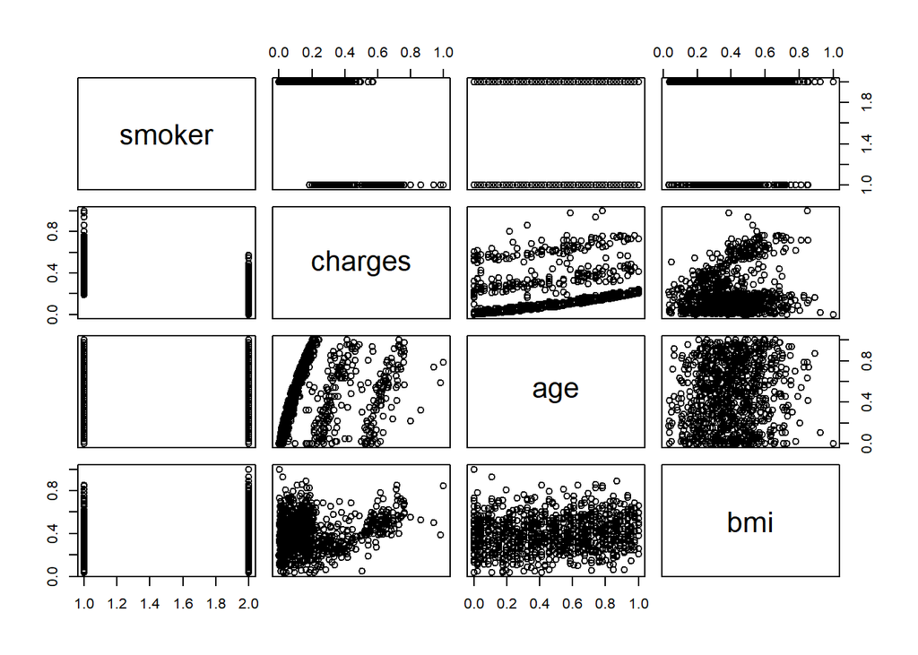

```r
set.seed(222)
ind <- sample(2, nrow(data), replace = TRUE, prob = c(0.7, 0.3))
training <- data[ind==1,]
testing <- data[ind==2,]
par(mfrow = c(1, 1))
plot(training)
```

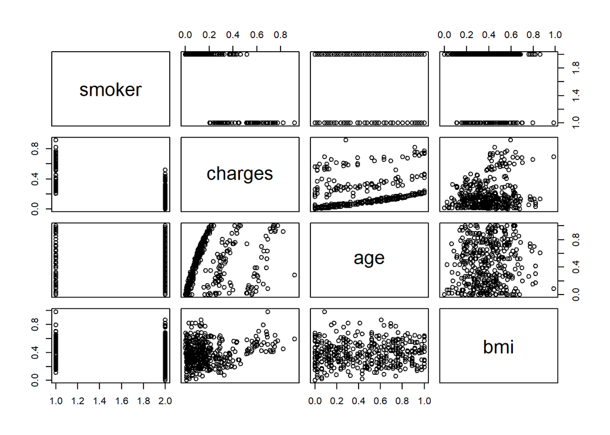

```r
plot(testing)
```

### 9.1.3 Creation and Training of the Neural Network

#### 9.1.3.1 Not deep NN - one single hidden layer

##### 9.1.3.1.1 Creation of NN_1

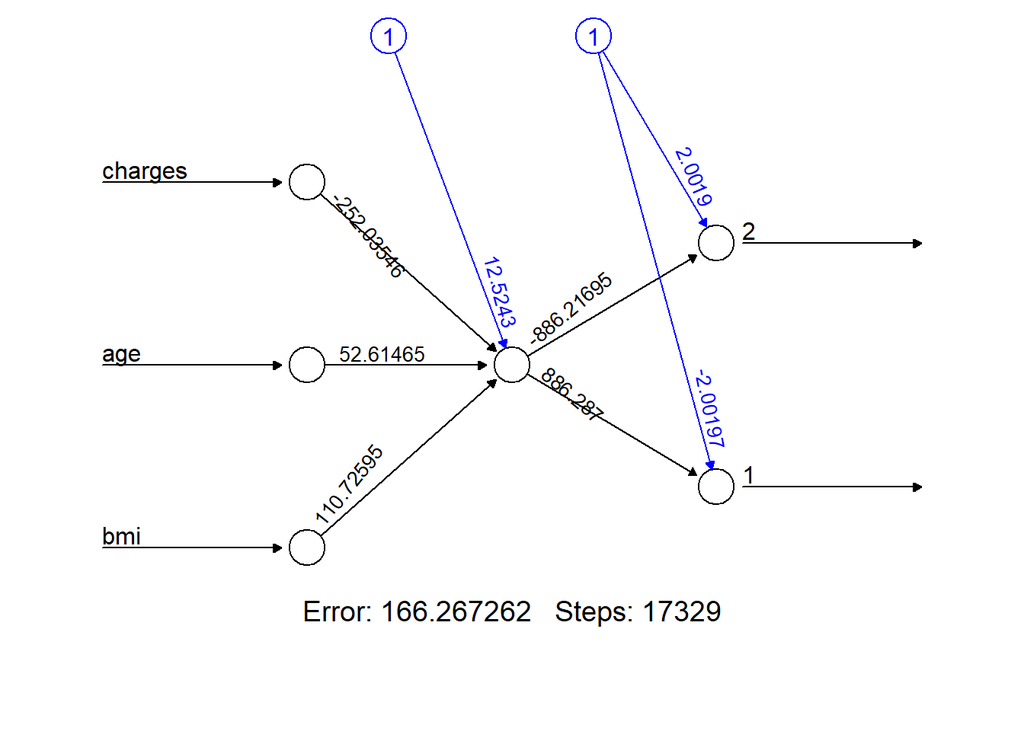

```r
set.seed(444)
nn <- neuralnet(smoker~charges + age + bmi,
               data = training,
               hidden = 1,
               err.fct = "ce",
               linear.output = FALSE)
#summary(nn)
#print(nn)
plot(nn, rep='best')
```

##### Prediction on training subset

```r
prediction_nn <- predict(nn,training)
#prediction_nn
class_nn <- apply(prediction_nn, 1, which.max)
```

##### 9.1.3.1.2 Confusion Matrix for training

```r
table(training$smoker, class_nn)
```

```
##    class_nn
##       1   2
##   1 197   0
##   2  27 711
```

```r
#training$smoker[1]
#class_nn[1]
```

##### 9.1.3.1.3 Performance for training

```r
levels(training$smoker)[class_nn[1]]
```

```
## [1] "2"
```

```r
corrects=sum(levels(training$smoker)[class_nn]==training$smoker)
errors=sum(levels(training$smoker)[class_nn]!=training$smoker)
(perf.nn=corrects/(corrects+errors))
```

```
## [1] 0.9711
```

```r
print(paste('training accuracy: ',perf.nn*100,"%"))
```

```
## [1] "training accuracy:  97.1122994652406 %"
```

##### 9.1.3.1.4 Prediction on test subset

```r
prediction_nn <- predict(nn,testing)
#prediction_nn
class_nn <- apply(prediction_nn, 1, which.max)
```

##### 9.1.3.1.5 Confusion Matrix for testing

```r
table(testing$smoker, class_nn)
```

```
##    class_nn
##       1   2
##   1  75   2
##   2  13 313
```

```r
#training$smoker[1]
#class_nn[1]
```

##### 9.1.3.1.6 Performance for testing

```r
levels(testing$smoker)[class_nn[1]]
```

```
## [1] "1"
```

```r
corrects=sum(levels(testing$smoker)[class_nn]==testing$smoker)
errors=sum(levels(testing$smoker)[class_nn]!=testing$smoker)
(perf.nn=corrects/(corrects+errors))
```

```
## [1] 0.9628
```

```r
print(paste('testing accuracy: ',perf.nn*100,"%"))
```

```
## [1] "testing accuracy:  96.2779156327543 %"
```

#### 9.1.3.2 Deep NN - two hidden layers

##### 9.1.3.2.1 Creation of NN_2

```r
set.seed(444)
nn2 <- neuralnet(smoker~charges + age + bmi,
               data = training,
               hidden = c(7,7),
               threshold = 0.0025,
               lifesign = 'full',
               lifesign.step = 500,
               linear.output = FALSE)
```

```
## hidden: 7, 7    thresh: 0.0025    rep: 1/1    steps:     500 min thresh: 0.11825064758526
##                                                         1000 min thresh: 0.112617356849393
##                                                         1500 min thresh: 0.112617356849393
##                                                         2000 min thresh: 0.107500337348156
##                                                         2500 min thresh: 0.0500175621736521
##                                                         3000 min thresh: 0.0219775031983741
##                                                         3500 min thresh: 0.0129098584782895
##                                                         4000 min thresh: 0.00367818486599488
##                                                         4441 error: 19.00295 time: 6.59 secs
```

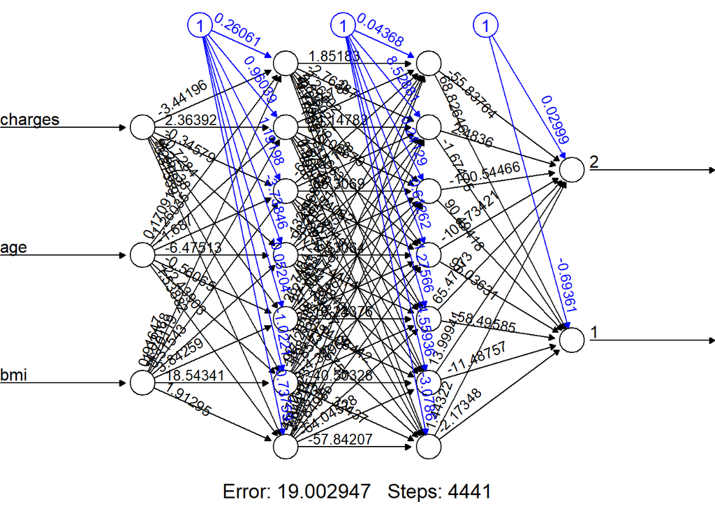

```r
#summary(nn)
#print(nn)
plot(nn2, rep='best')
```

##### 9.1.3.2.2 Prediction on training subset

```r
prediction_nn2 <- predict(nn2,training)
#prediction_nn
class_nn <- apply(prediction_nn2, 1, which.max)
```

##### 9.1.3.2.3 Confusion Matrix for training

```r
table(training$smoker, class_nn)
```

```
##    class_nn
##       1   2
##   1 197   0
##   2  19 719
```

```r
#training$smoker[1]
#class_nn[1]
```

##### 9.1.3.2.4 Performance for training

```r
levels(training$smoker)[class_nn[1]]
```

```
## [1] "2"
```

```r
corrects=sum(levels(training$smoker)[class_nn]==training$smoker)
errors=sum(levels(training$smoker)[class_nn]!=training$smoker)
(perf.nn=corrects/(corrects+errors))
```

```
## [1] 0.9797
```

```r
print(paste('training accuracy: ',perf.nn*100,"%"))
```

```
## [1] "training accuracy:  97.9679144385027 %"
```

##### 9.1.3.2.5 Prediction on test subset

```r
prediction_nn2 <- predict(nn2,testing)
#prediction_nn
class_nn <- apply(prediction_nn2, 1, which.max)
```

##### 9.1.3.2.6 Confusion Matrix for testing

```r
table(testing$smoker, class_nn)
```

```
##    class_nn
##       1   2
##   1  74   3
##   2  12 314
```

```r
#training$smoker[1]
#class_nn[1]
```

##### 9.1.3.2.7 Performance for testing

```r
levels(testing$smoker)[class_nn[1]]
```

```
## [1] "1"
```

```r
corrects=sum(levels(testing$smoker)[class_nn]==testing$smoker)
errors=sum(levels(testing$smoker)[class_nn]!=testing$smoker)
(perf.nn=corrects/(corrects+errors))
```

```
## [1] 0.9628
```

```r
print(paste('testing accuracy: ',perf.nn*100,"%"))
```

```
## [1] "testing accuracy:  96.2779156327543 %"
```

#### 9.1.3.3 Deep NN - three hidden layers

##### 9.1.3.3.1 Creation of NN_3

```r
set.seed(444)
nn3 <- neuralnet(smoker~charges + age + bmi,
               data = training,
               hidden = c(3,2,1),
               threshold = 0.0025,
               lifesign = 'full',
               lifesign.step = 500,
               linear.output = FALSE)
```

```
## hidden: 3, 2, 1    thresh: 0.0025    rep: 1/1    steps:     500  min thresh: 0.0938559883189038
##                                                            1000  min thresh: 0.0938559883189038
##                                                            1500  min thresh: 0.0938559883189038
##                                                            2000  min thresh: 0.0938559883189038
##                                                            2500  min thresh: 0.0779042619497504
##                                                            3000  min thresh: 0.0477729129630322
##                                                            3500  min thresh: 0.0477729129630322
##                                                            4000  min thresh: 0.0477729129630322
##                                                            4500  min thresh: 0.0477729129630322
##                                                            5000  min thresh: 0.0477729129630322
##                                                            5500  min thresh: 0.0477729129630322
##                                                            6000  min thresh: 0.0477729129630322
##                                                            6500  min thresh: 0.0477729129630322
##                                                            7000  min thresh: 0.0477729129630322
##                                                            7500  min thresh: 0.0401919383687264
```

[output cut: 20 more lines]

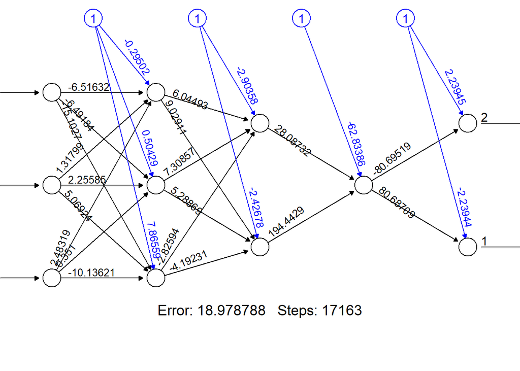

```r
#summary(nn)
#print(nn)
plot(nn3, rep='best')
```

##### 9.1.3.3.2 Prediction on training subset

```r
prediction_nn3 <- predict(nn3,training)
#prediction_nn
class_nn <- apply(prediction_nn3, 1, which.max)
```

##### 9.1.3.3.3 Confusion Matrix for training

```r
table(training$smoker, class_nn)
```

```
##    class_nn
##       1   2
##   1 197   0
##   2  21 717
```

```r
#training$smoker[1]
#class_nn[1]
```

##### 9.1.3.3.4 Performance for training

```r
levels(training$smoker)[class_nn[1]]
```

```
## [1] "2"
```

```r
corrects=sum(levels(training$smoker)[class_nn]==training$smoker)
errors=sum(levels(training$smoker)[class_nn]!=training$smoker)
(perf.nn=corrects/(corrects+errors))
```

```
## [1] 0.9775
```

```r
print(paste('training accuracy: ',perf.nn*100,"%"))
```

```
## [1] "training accuracy:  97.7540106951872 %"
```

##### 9.1.3.3.5 Prediction on test subset

```r
prediction_nn3 <- predict(nn3,testing)
#prediction_nn
class_nn <- apply(prediction_nn3, 1, which.max)
```

##### 9.1.3.3.6 Confusion Matrix for testing

```r
table(testing$smoker, class_nn)
```

```
##    class_nn
##       1   2
##   1  76   1
##   2   9 317
```

```r
#training$smoker[1]
#class_nn[1]
```

##### 9.1.3.3.7 Performance for testing

```r
levels(testing$smoker)[class_nn[1]]
```

```
## [1] "1"
```

```r
corrects=sum(levels(testing$smoker)[class_nn]==testing$smoker)
errors=sum(levels(testing$smoker)[class_nn]!=testing$smoker)
(perf.nn=corrects/(corrects+errors))
```

```
## [1] 0.9752
```

```r
print(paste('testing accuracy: ',perf.nn*100,"%"))
```

```
## [1] "testing accuracy:  97.5186104218362 %"
```

## 9.2 Neural Networks using “h20”

### 9.2.1 Creation NN

```r
set.seed(99)
h2o.init()
```

[output not shown]

```r
train_hf <- as.h2o(training)
model_dl <- h2o.deeplearning(x = 2:4, y = 1, training_frame = train_hf, nfolds = 10, seed=545, verbose = TRUE)
```

[output not shown]

### 9.2.2 Prediction on training

```r
predicted_h20_deep_neural_network_probabilites_train <- h2o.predict(model_dl, train_hf)
table( as.data.frame(predicted_h20_deep_neural_network_probabilites_train$predict))
```

```
##
##   1   2
## 226 709
```

```r
predicted_h20_deep_neural_network_class_train <- as.data.frame(predicted_h20_deep_neural_network_probabilites_train$predict)
```

### 9.2.3 Performance on training

```r
table(training$smoker, as.integer(predicted_h20_deep_neural_network_class_train[,1]))
```

```
##
##       1   2
##   1 197   0
##   2  29 709
```

```r
predicted_h20_deep_neural_network_performance_train <- mean(as.integer(predicted_h20_deep_neural_network_class_train[,1]) == (training$smoker))*100
print(paste('training accuracy: ',predicted_h20_deep_neural_network_performance_train,"%"))
```

```
## [1] "training accuracy:  96.8983957219251 %"
```

### 9.2.4 Prediction on testing

```r
test_hf <- as.h2o(testing)
predicted_h20_deep_neural_network_probabilites_test <- h2o.predict(model_dl, test_hf)
table( as.data.frame(predicted_h20_deep_neural_network_probabilites_test$predict))
```

```
##
##   1   2
##  87 316
```

```r
predicted_h20_deep_neural_network_class_test <- as.data.frame(predicted_h20_deep_neural_network_probabilites_test$predict)
```

### 9.2.5 Performance on testing

```r
table(testing$smoker, as.integer(predicted_h20_deep_neural_network_class_test[,1]))
```

```
##
##       1   2
##   1  74   3
##   2  13 313
```

```r
predicted_h20_deep_neural_network_performance_test <- mean(as.integer(predicted_h20_deep_neural_network_class_test[,1]) == (testing$smoker))*100
print(paste('testing accuracy: ',predicted_h20_deep_neural_network_performance_test,"%"))
```

```
## [1] "testing accuracy:  96.029776674938 %"
```

## 9.3 Results and method comparison

[output not shown]

In the above table you can find the latest results for all created models which are nearly the same. Based on the sample results, there is no huge difference between using the neuralnet package or the h2o package. Moreover the parameters for the hidden layer were chosen by a trial and error approach. We tried to create different levels for the hidden parameter, to explore if the performance will increase with the given complexity. Since the results are not reflecting this assumption and all performance results are in the same range, all models can be used for an adequate classification, whether a person is a smoker or not.

# 10 Cross validation and discussion

## 10.1 Model overview

Throughout the analysis, many different model are applied. Here is a quick overview of the models used that performed the best:

### 10.1.1 Linear models (standard lm)

```r
lm.insurance.3$call #best lm
```

```
## lm(formula = charges ~ age + bmi + children + smoker + bmi:smoker,
##     data = insurance)
```

```r
lm.insurance.all$call # lm with all variables
```

```
## lm(formula = charges ~ age + sex + bmi + children + smoker +
##     region, data = insurance)
```

### 10.1.2 Polynomial and GAM

```r
lm.insurance.5$call
```

```
## lm(formula = age ~ sex + bmi + children + charges + I(charges^2),
##     data = insurance)
```

```r
gam.insurance.1$call
```

```
## gam(formula = age ~ sex + s(charges) + children, data = insurance)
```

### 10.1.3 GLM

```r
glm.children$call
```

```
## glm(formula = children ~ smoker + charges, family = "poisson",
##     data = insurance)
```

```r
glm.smoker.2$call
```

```
## glm(formula = smoker ~ age + bmi + charges, family = "binomial",
##     data = insurance)
```

### 10.1.4 Decision Trees

```r
tree.regression.bmi$call #regression tree
```

```
## tree(formula = bmi ~ ., data = insurance)
```

```r
tree.regression.charges$call #regression tree
```

```
## tree(formula = charges ~ ., data = insurance)
```

```r
tree.regression.bmi.pruned$call #regression tree pruned
```

```
## snip.tree(tree = tree.regression.bmi2, nodes = 9L)
```

```r
bag.insurance$call #regression tree bagged
```

```
## bagging.data.frame(formula = charges ~ ., data = insurance, subset = train,
##     nbagg = 20, coob = TRUE)
```

```r
bag.insurance.2$call #regression tree bagged random forest
```

```
## randomForest(formula = charges ~ ., data = insurance, mtry = 6,
##     importance = TRUE, subset = train)
```

```r
rf.insurance$call #random forest
```

```
## randomForest(formula = charges ~ ., data = insurance, mtry = 2,
##     importance = TRUE, subset = train)
```

### 10.1.5 Support Vector Machines

```r
bestmod$call #svm
```

```
## best.tune(method = svm, train.x = smoker ~ charges + bmi, data = insurance.train,
##     ranges = list(cost = cost_range), kernel = "linear")
```

```r
bestmod.poly$call #svm polynomial
```

```
## best.tune(method = svm, train.x = smoker ~ charges + bmi, data = insurance.train,
##     ranges = list(cost = cost_range, degree = degree_range),
##     kernel = "polynomial")
```

### 10.1.6 Neural Networks

```r
nn3$call
```

```
## neuralnet(formula = smoker ~ charges + age + bmi, data = training,
##     hidden = c(3, 2, 1), threshold = 0.0025, lifesign = "full",
##     lifesign.step = 500, linear.output = FALSE)
```

## 10.2 Cross validation

As the models have different dependent variables and are different types (regression/classification) it is difficult to compare all numerically. To do a cross validation, the regression models with charges as dependent variables are compared and the same for classification models with dependent variable smoker.

### 10.2.1 Regression (dependent variable “charges”)

The in sample performance, using R Squared as measure is the following for the 3 selected models.

```r
summary(lm.insurance.3)$r.squared
```

```
## [1] 0.8388
```

```r
summary(lm.insurance.all)$r.squared
```

```
## [1] 0.7509
```

```r
summary(tree.regression.charges)
```

```
##
## Regression tree:
## tree(formula = charges ~ ., data = insurance)
## Variables actually used in tree construction:
## [1] "smoker"   "age"      "children" "bmi"
## Number of terminal nodes:  7
## Residual mean deviance:  0.159 = 212 / 1330
## Distribution of residuals:
##    Min. 1st Qu.  Median    Mean 3rd Qu.    Max.
## -0.9870 -0.1970 -0.0500  0.0000  0.0994  2.4500
```

As decision trees do not work with an R-squared value per se, we take the residual mean deviance for the decision trees (here at 0.1592). The residual mean deviance (0.1592) can be considered as R-squared error. Interpreting error as 1 - R-squared, we receive roughly similar values for the three variables.

The out of sample performance is computed by using 50:50 training and test data and repeating the process 100 times.

```r
set.seed(5)


RMSE.1 <- c()
RMSE.2 <- c()
RMSE.3 <- c()
RMSE.4 <- c()


for(i in 1:100){

  train.YES <- sample(x = c(TRUE, FALSE),
                      size = nrow(insurance),
                      replace = TRUE)

  insurance.train <- insurance[train.YES, ]

  insurance.test <- insurance[!train.YES, ]


  # fit model with train data

  lm.insurance.3.train <- lm(formula = formula(lm.insurance.3),
                   data = insurance.train)

  lm.insurance.all.train <- lm(formula = formula(lm.insurance.all),
                   data = insurance.train)

  tree.regression.charges.train <- lm(formula = formula(tree.regression.charges),
                   data = insurance.train)

  rf.insurance.train <- lm(formula = formula(rf.insurance),
                   data = insurance.train)


  # make prediction on test data
  lm.insurance.3.predict <- predict(lm.insurance.3.train,
                          newdata = insurance.test)

  lm.insurance.all.predict <- predict(lm.insurance.all.train,
                          newdata = insurance.test)

  tree.regression.charges.predict <- predict(tree.regression.charges.train,
                          newdata = insurance.test)

  rf.insurance.predict <- predict(rf.insurance.train,
                          newdata = insurance.test)


  #RMSE

  RMSE.1[i] <- rmse(lm.insurance.3.predict, insurance.test$charges)
  RMSE.2[i] <- rmse(lm.insurance.all.predict, insurance.test$charges)
  RMSE.3[i] <- sqrt((sum(tree.regression.charges.predict-insurance.test[7])^2)/length(tree.regression.charges.predict))



    }
```

The out of sample performance, using RMSE as measure is the following:

```r
#lm.3
mean(RMSE.1)
```

```
## [1] 4889.887
```

```r
#lm.all
mean(RMSE.2)
```

```
## [1] 6101.809
```

```r
#tree regression
mean(RMSE.3)
```

```
## [1] 6128.905
```

As one can see, the best linear model also performs in cross-validation as the better in comparison with the linear model with all variables as well as the decision tree. This is not very astonishing, as with more variables, the more variance once gets.

What is interesting to see, is that the lm modell with all the variables and the regression tree perform very similarly, albeit not with the best values.

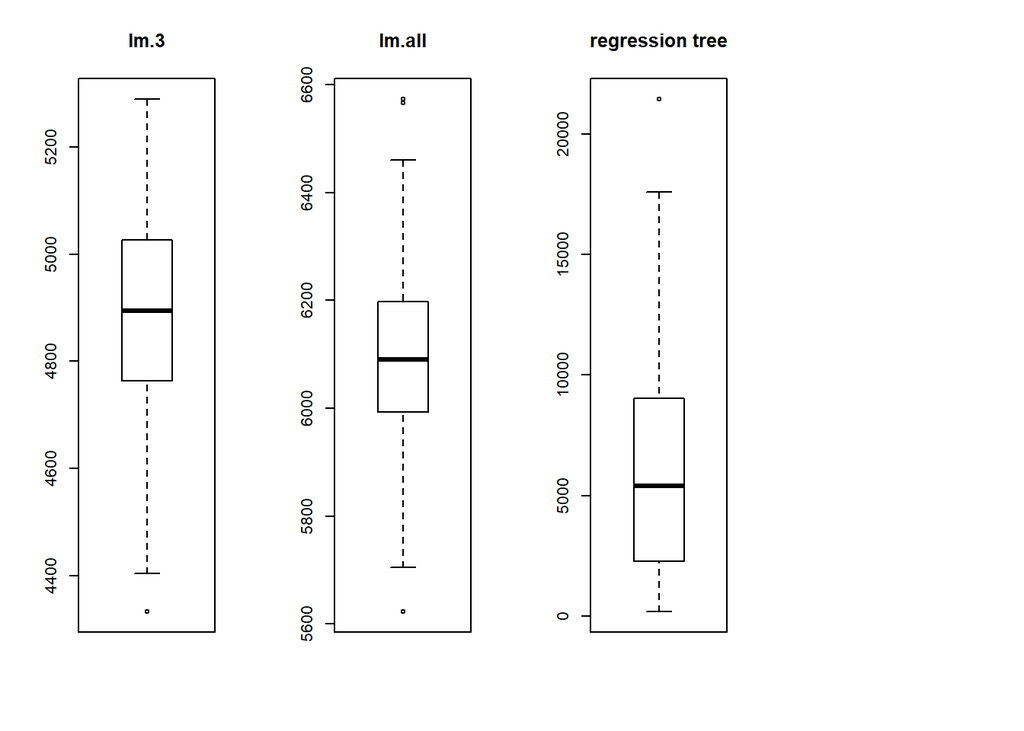

```r
par(mfrow=c(1,4))
boxplot(RMSE.1, main="lm.3")
boxplot(RMSE.2, main="lm.all")
boxplot(RMSE.3, main="regression tree")
```

When having a closer look at the boxplots however, one can see the difference in the methods. The linear models perform very regularily and very symmetrically, whereas decision trees have a much larger distribution.

Here, one can alsi directly see the importance of cross-validation: as one practically plays with the chances when performing a train <-> test approach, one cannot take such results as true. It can be that one ends up on either end of the scale / boxplot.

### 10.2.2 Classification (Dependent Variable “smoker”)

Throughout the analysis, 3 models have been used to make a classification for smoker/non-smoker. Those models will be cross validated:

```r
glm.smoker.2$call #glm
```

```
## glm(formula = smoker ~ age + bmi + charges, family = "binomial",
##     data = insurance)
```

```r
bestmod$call #svm
```

```
## best.tune(method = svm, train.x = smoker ~ charges + bmi, data = insurance.train,
##     ranges = list(cost = cost_range), kernel = "linear")
```

```r
nn3$call #neural network
```

```
## neuralnet(formula = smoker ~ charges + age + bmi, data = training,
##     hidden = c(3, 2, 1), threshold = 0.0025, lifesign = "full",
##     lifesign.step = 500, linear.output = FALSE)
```

```r
set.seed(5)

MC.1 <- c()
MC.2 <- c()
MC.3 <- c()


for(i in 1:10){

  train.YES <- sample(x = c(TRUE, FALSE),
                      size = nrow(insurance),
                      replace = TRUE)

  insurance.train <- insurance[train.YES, ]

  insurance.test <- insurance[!train.YES, ]

  insurance.train.normalized <-dplyr::select(insurance.train, smoker, charges, age, bmi)
  insurance.test.normalized <-dplyr::select(insurance.test, smoker, charges, age, bmi)


  # Min-Max Normalization for neural networks
  insurance.train.normalized$charges <- (insurance.train.normalized$charges - min(insurance.train.normalized$charges))/(max(insurance.train.normalized$charges) - min(insurance.train.normalized$charges))
  insurance.train.normalized$age <- (insurance.train.normalized$age - min(insurance.train.normalized$age))/(max(insurance.train.normalized$age) - min(insurance.train.normalized$age))
  insurance.train.normalized$bmi <- (insurance.train.normalized$bmi - min(insurance.train.normalized$bmi))/(max(insurance.train.normalized$bmi)-min(insurance.train.normalized$bmi))


  insurance.test.normalized$charges <- (insurance.test.normalized$charges - min(insurance.test.normalized$charges))/(max(insurance.test.normalized$charges) - min(insurance.test.normalized$charges))
  insurance.test.normalized$age <- (insurance.test.normalized$age - min(insurance.test.normalized$age))/(max(insurance.test.normalized$age) - min(insurance.test.normalized$age))
  insurance.test.normalized$bmi <- (insurance.test.normalized$bmi - min(insurance.test.normalized$bmi))/(max(insurance.test.normalized$bmi)-min(insurance.test.normalized$bmi))


  # fit model with train data

  mod.1 <- glm(formula = smoker ~ age + bmi + charges, family = "binomial",
               data = insurance.train)

  mod.2 <- svm(smoker~charges+bmi, data = insurance.train, cost =5)

  nn3 <- neuralnet(smoker~charges + age + bmi,
                   data = insurance.train.normalized,
                   hidden = c(3,2,1),
                   threshold = 0.0025,
                   lifesign = 'full',
                   lifesign.step = 500,
                   linear.output = FALSE)


  # make prediction on test data

  #mod1
  mod.1.pred <- predict(mod.1, newdata = insurance.test, type="response")
  mod.1.pred.binomial <- ifelse(mod.1.pred > 0.5, yes = 1, no = 0)
  df.mod.1.pred <- data.frame(obs = insurance.test$smoker, fitted = mod.1.pred.binomial)
  mc.table.1 <- table(obs = df.mod.1.pred$obs,fit = df.mod.1.pred$fitted)
  MC.1[i] <- (mc.table.1[2]+mc.table.1[3])/(mc.table.1[2]+mc.table.1[3]+mc.table.1[1]+mc.table.1[4])

  #mod2
  mod.2.pred <- predict(mod.2, newdata = insurance.test)
  df.mod.2.pred <- data.frame(obs = insurance.test$smoker, fitted = mod.2.pred)
  mc.table.2 <- table(obs = df.mod.2.pred$obs,fit = df.mod.2.pred$fitted)
  MC.2[i] <- (mc.table.2[2]+mc.table.2[3])/(mc.table.2[2]+mc.table.2[3]+mc.table.2[1]+mc.table.2[4])

  #mod3

  prediction_nn3 <- predict(nn3,insurance.test.normalized)
  class_nn <- apply(prediction_nn3, 1, which.max)
  df.mod.3.pred <- data.frame(obs = insurance.test$smoker, fitted = class_nn)
  mc.table.3 <- table(obs = df.mod.3.pred$obs,fit = df.mod.3.pred$fitted)
  MC.3[i] <- (mc.table.3[2]+mc.table.3[3])/(mc.table.3[2]+mc.table.3[3]+mc.table.3[1]+mc.table.3[4])

}
```

The following are the misclassification rates of our models:

```r
#misclassification rates of the models
#glm
mean(MC.1)
```

```
## [1] 0.0462371
```

```r
#svm
mean(MC.2)
```

```
## [1] 0.042029
```

```r
#neuralnet
mean(MC.3)
```

```
## [1] 0.05506842
```

We can observe that all models have a misclassification rate of around 4-5.5%. The model that performs best is the svm. The model that perfoms worst, but still reasonably well is the neural network.

### 10.2.3 Cross-Validation for Classification Trees

We recall the classification errors in the above code:

```r
(tree.classification.region.pred.error.1)
```

```
## [1] 0.642094
```

```r
(tree.classification.region.pred.error.2)
```

```
## [1] 0.8781095
```

We now recheck if misclassification improves when cross-validiting by a 10fold crossvalidations our model:

```r
n <- nrow(insurance)
K <- 10
size <- n%/%K
set.seed(5)
alea <- runif(n)
rang <- rank(alea)
bloc <- (rang-1)%/%size+1
bloc <- as.factor(bloc)
print(summary(bloc)) #Anzahl Datensätze und Daten pro Dign
```

```
##   1   2   3   4   5   6   7   8   9  10  11
## 133 133 133 133 133 133 133 133 133 133   8
```

```r
library(rpart)
pred <- predict(tree.classification.region_all, newdata = insurance, type = "class")
mc <- table(insurance$region, pred) #missclassification
print(mc)
```

```
##    pred
##       0   1   2   3
##   0 211   0   0 153
##   1 112   0   0 213
##   2 105   0   0 219
##   3  74   0   0 251
```

```r
all.err <- numeric(0)
for (k in 1:K) {
  baum <- rpart(region ~., data = insurance[bloc!=k,], method="class")
  pred <- predict(baum, newdata=insurance[bloc==k,], type = "class")
  mc <- table(insurance$region[bloc==k], pred)
  err <- 1.0 -(mc[1,1]+mc[2,2]+mc[3,3]+mc[4,4])/sum(mc)
  #print(err)
  all.err <- rbind(all.err,err)

}

#print(all.err)

err.cv <- mean(all.err)
print(err.cv)
```

```
## [1] 0.6699248
```

We see here that with 66.99%, our misclassification error has not much improved with crossvalidation. In fact, it even has gotten a bit worse in comparison with tree.classification.region.pred.error.1.

# 11 Final words

In the analysed data set, we got a lot of different insights on various sides. We learned that not every variable might be of importance for certain forecasts - or at least that not enough data is available at the time in order to do so. We think here of the variable “region” which performed not very good in terms of prediction for most of the models.

Then there is the other side of performance: models that can predict at a very good rate if somebody is a smoker or not, with an astonishingly low error margin of 5%.

All in all, it was very interesting to see the theory performing in practice and to get to know what kind of insights one receives by these machine learning technique hands on.

And “most” importantly, what we learned in this project and which is clearly documented: smoking is not only bad for the health, it is also bad for ones wallet. Never smoke, kids!